# PSI Project: Logistic Regression

### Preliminaries

```r
needed_packages <- c("pastecs", "ggplot2", "psych", "semTools", "FSA", "sjstats", "userfriendlyscience","corrplot")
not_installed <- needed_packages[!(needed_packages %in% installed.packages()[ , "Package"])]
if(length(not_installed)) install.packages(not_installed)

library(pastecs)
library(ggplot2)
library(psych)
library(semTools)
library(FSA)
library(sjstats)
library(userfriendlyscience)
library(corrplot)
```

```r
needed_packages <- c("foreign",  "Epi", "arm", "DescTools", "stargazer", "lmtest",  "car", "generalhoslem","regclass","coda","VIM","ggplot2","pastecs","FSA")
not_installed <- needed_packages[!(needed_packages %in% installed.packages()[ , "Package"])]
if(length(not_installed)) install.packages(not_installed, repos = "http://cran.us.r-project.org")

library(Epi)
library(DescTools)
library(stargazer)
library(foreign)
library(coda)
library(arm)
library(lmtest)
library(car)
library(generalhoslem)
library("regclass")
library(dplyr)
library("VIM")
```

## Data preparation

The target variable is changed from character to integer.

```r
#Read Math dataset from CSV
bank=read.table("bank-additional-full.csv",sep=";",header=TRUE)
bank$y_new<-case_when(bank$y=="yes" ~ 1,
                     TRUE ~ 0)

summary(bank)
```

```
##       age            job              marital           education
##  Min.   :17.00   Length:41188       Length:41188       Length:41188
##  1st Qu.:32.00   Class :character   Class :character   Class :character
##  Median :38.00   Mode  :character   Mode  :character   Mode  :character
##  Mean   :40.02
##  3rd Qu.:47.00
##  Max.   :98.00
##    default            housing              loan             contact
##  Length:41188       Length:41188       Length:41188       Length:41188
##  Class :character   Class :character   Class :character   Class :character
##  Mode  :character   Mode  :character   Mode  :character   Mode  :character
##
##
##
##     month           day_of_week           duration         campaign
##  Length:41188       Length:41188       Min.   :   0.0   Min.   : 1.000
##  Class :character   Class :character   1st Qu.: 102.0   1st Qu.: 1.000
##  Mode  :character   Mode  :character   Median : 180.0   Median : 2.000
##                                        Mean   : 258.3   Mean   : 2.568
##                                        3rd Qu.: 319.0   3rd Qu.: 3.000
##                                        Max.   :4918.0   Max.   :56.000
##      pdays          previous       poutcome          emp.var.rate
##  Min.   :  0.0   Min.   :0.000   Length:41188       Min.   :-3.40000
##  1st Qu.:999.0   1st Qu.:0.000   Class :character   1st Qu.:-1.80000
##  Median :999.0   Median :0.000   Mode  :character   Median : 1.10000
##  Mean   :962.5   Mean   :0.173                      Mean   : 0.08189
##  3rd Qu.:999.0   3rd Qu.:0.000                      3rd Qu.: 1.40000
##  Max.   :999.0   Max.   :7.000                      Max.   : 1.40000
##  cons.price.idx  cons.conf.idx     euribor3m      nr.employed
##  Min.   :92.20   Min.   :-50.8   Min.   :0.634   Min.   :4964
##  1st Qu.:93.08   1st Qu.:-42.7   1st Qu.:1.344   1st Qu.:5099
##  Median :93.75   Median :-41.8   Median :4.857   Median :5191
##  Mean   :93.58   Mean   :-40.5   Mean   :3.621   Mean   :5167
##  3rd Qu.:93.99   3rd Qu.:-36.4   3rd Qu.:4.961   3rd Qu.:5228
##  Max.   :94.77   Max.   :-26.9   Max.   :5.045   Max.   :5228
##       y                 y_new
##  Length:41188       Min.   :0.0000
##  Class :character   1st Qu.:0.0000
##  Mode  :character   Median :0.0000
##                     Mean   :0.1127
##                     3rd Qu.:0.0000
##                     Max.   :1.0000
```

## Handling missing data

In the data set all the missing data are represented as unknown. Let’s convert them to NA and check if there is any pattern present in the missing data.

Covert all the categorical attributes to factors.

```r
bank$job<-case_when(bank$job=="unknown" ~ NA_character_ ,
                     TRUE ~ bank$job)
bank$job<-as.factor(bank$job)
bank$marital<-case_when(bank$marital=="unknown" ~ NA_character_ ,
                     TRUE ~ bank$marital)
bank$marital<-as.factor(bank$marital)

bank$education<-case_when(bank$education=="unknown" ~ NA_character_ ,
                     TRUE ~ bank$education)
bank$education<-as.factor(bank$education)

bank$default<-case_when(bank$default=="unknown" ~ NA_character_ ,
                     TRUE ~ bank$default)
bank$default<-as.factor(bank$default)

bank$housing<-case_when(bank$housing=="unknown" ~ NA_character_ ,
                     TRUE ~ bank$housing)
bank$housing<-as.factor(bank$housing)

bank$loan<-case_when(bank$loan=="unknown" ~ NA_character_ ,
                     TRUE ~ bank$loan)
bank$loan<-as.factor(bank$loan)


bank$contact<-as.factor(bank$contact)
bank$month<-as.factor(bank$month)
bank$day_of_week<-as.factor(bank$day_of_week)
bank$poutcome<-as.factor(bank$poutcome)
bank$y<-as.factor(bank$y)

summary(bank)
```

```
##       age                 job            marital
##  Min.   :17.00   admin.     :10422   divorced: 4612
##  1st Qu.:32.00   blue-collar: 9254   married :24928
##  Median :38.00   technician : 6743   single  :11568
##  Mean   :40.02   services   : 3969   NA's    :   80
##  3rd Qu.:47.00   management : 2924
##  Max.   :98.00   (Other)    : 7546
##                  NA's       :  330
##                education     default      housing        loan
##  university.degree  :12168   no  :32588   no  :18622   no  :33950
##  high.school        : 9515   yes :    3   yes :21576   yes : 6248
##  basic.9y           : 6045   NA's: 8597   NA's:  990   NA's:  990
##  professional.course: 5243
##  basic.4y           : 4176
##  (Other)            : 2310
##  NA's               : 1731
##       contact          month       day_of_week    duration
##  cellular :26144   may    :13769   fri:7827    Min.   :   0.0
##  telephone:15044   jul    : 7174   mon:8514    1st Qu.: 102.0
##                    aug    : 6178   thu:8623    Median : 180.0
##                    jun    : 5318   tue:8090    Mean   : 258.3
##                    nov    : 4101   wed:8134    3rd Qu.: 319.0
##                    apr    : 2632               Max.   :4918.0
##                    (Other): 2016
##     campaign          pdays          previous            poutcome
##  Min.   : 1.000   Min.   :  0.0   Min.   :0.000   failure    : 4252
##  1st Qu.: 1.000   1st Qu.:999.0   1st Qu.:0.000   nonexistent:35563
##  Median : 2.000   Median :999.0   Median :0.000   success    : 1373
##  Mean   : 2.568   Mean   :962.5   Mean   :0.173
##  3rd Qu.: 3.000   3rd Qu.:999.0   3rd Qu.:0.000
##  Max.   :56.000   Max.   :999.0   Max.   :7.000
##
##   emp.var.rate      cons.price.idx  cons.conf.idx     euribor3m
##  Min.   :-3.40000   Min.   :92.20   Min.   :-50.8   Min.   :0.634
##  1st Qu.:-1.80000   1st Qu.:93.08   1st Qu.:-42.7   1st Qu.:1.344
##  Median : 1.10000   Median :93.75   Median :-41.8   Median :4.857
##  Mean   : 0.08189   Mean   :93.58   Mean   :-40.5   Mean   :3.621
##  3rd Qu.: 1.40000   3rd Qu.:93.99   3rd Qu.:-36.4   3rd Qu.:4.961
##  Max.   : 1.40000   Max.   :94.77   Max.   :-26.9   Max.   :5.045
##
##   nr.employed     y             y_new
##  Min.   :4964   no :36548   Min.   :0.0000
##  1st Qu.:5099   yes: 4640   1st Qu.:0.0000
##  Median :5191               Median :0.0000
##  Mean   :5167               Mean   :0.1127
##  3rd Qu.:5228               3rd Qu.:0.0000
##  Max.   :5228               Max.   :1.0000
##
```

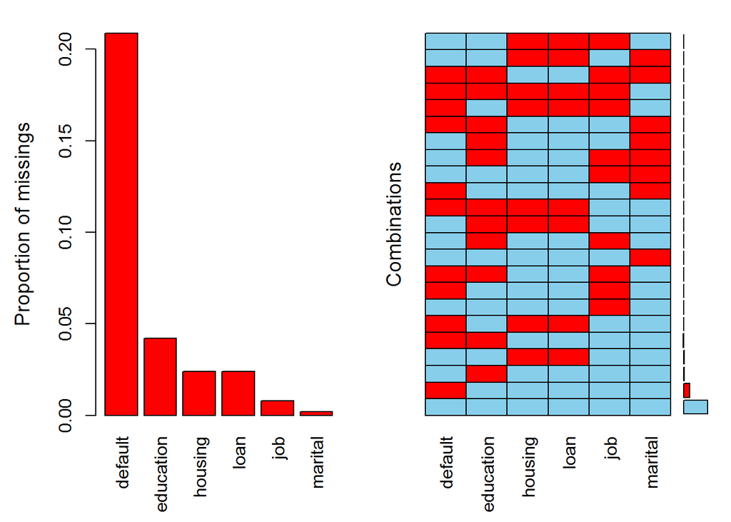

```
##
##  Variables sorted by number of missings:
##   Variable       Count
##    default 0.208725842
##  education 0.042026804
##    housing 0.024036127
##       loan 0.024036127
##        job 0.008012042
##    marital 0.001942313
```

```r
#Create and inspect patterns of missingness
res<-summary(VIM::aggr(bank[,c('job','marital','education','default','housing','loan')], sortVar=TRUE))$combinations
```

```r
res$Percent<-round(res$Percent,2)
head(res[rev(order(res[,2])),],10)
```

|  | Combinations | Count | Percent |
| --- | --- | --- | --- |
| 1 | 0:0:0:0:0:0 | 30488 | 74.02 |
| 3 | 0:0:0:1:0:0 | 7757 | 18.83 |
| 5 | 0:0:1:0:0:0 | 1102 | 2.68 |
| 2 | 0:0:0:0:1:1 | 739 | 1.79 |
| 7 | 0:0:1:1:0:0 | 456 | 1.11 |
| 4 | 0:0:0:1:1:1 | 207 | 0.50 |
| 14 | 1:0:0:0:0:0 | 116 | 0.28 |
| 16 | 1:0:0:1:0:0 | 76 | 0.18 |
| 19 | 1:0:1:1:0:0 | 70 | 0.17 |
| 9 | 0:1:0:0:0:0 | 59 | 0.14 |

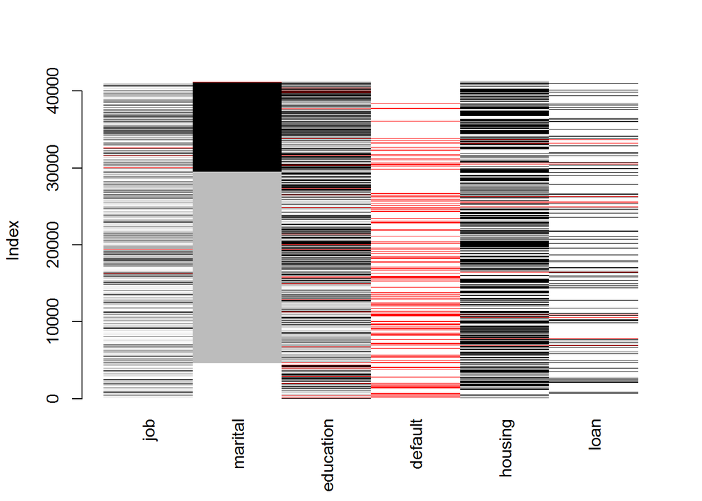

```r
#metrics plot
VIM::matrixplot(bank[,c('job','marital','education','default','housing','loan')], sortby = 2)
```

```r
summary(bank[is.na(bank$loan),])
```

```
##       age                 job          marital                  education
##  Min.   :17.00   blue-collar:240   divorced:121   university.degree  :277
##  1st Qu.:32.00   admin.     :227   married :588   high.school        :220
##  Median :38.00   technician :147   single  :280   basic.9y           :151
##  Mean   :39.95   services   :101   NA's    :  1   professional.course:125
##  3rd Qu.:47.00   management : 71                  basic.4y           :117
##  Max.   :86.00   (Other)    :199                  (Other)            : 60
##                  NA's       :  5                  NA's               : 40
##  default    housing      loan          contact        month     day_of_week
##  no  :763   no  :  0   no  :  0   cellular :561   may    :350   fri:203
##  yes :  0   yes :  0   yes :  0   telephone:429   jun    :175   mon:191
##  NA's:227   NA's:990   NA's:990                   jul    :147   thu:189
##                                                   aug    :130   tue:210
##                                                   nov    : 76   wed:197
##                                                   apr    : 58
##                                                   (Other): 54
##     duration         campaign          pdays          previous
##  Min.   :   7.0   Min.   : 1.000   Min.   :  2.0   Min.   :0.0000
##  1st Qu.: 102.0   1st Qu.: 1.000   1st Qu.:999.0   1st Qu.:0.0000
##  Median : 169.0   Median : 2.000   Median :999.0   Median :0.0000
##  Mean   : 250.2   Mean   : 2.561   Mean   :964.9   Mean   :0.1848
##  3rd Qu.: 304.2   3rd Qu.: 3.000   3rd Qu.:999.0   3rd Qu.:0.0000
##  Max.   :2926.0   Max.   :56.000   Max.   :999.0   Max.   :4.0000
##
##         poutcome    emp.var.rate     cons.price.idx  cons.conf.idx
##  failure    :111   Min.   :-3.4000   Min.   :92.20   Min.   :-50.80
##  nonexistent:851   1st Qu.:-1.8000   1st Qu.:93.08   1st Qu.:-42.70
##  success    : 28   Median : 1.1000   Median :93.92   Median :-41.80
##                    Mean   : 0.1134   Mean   :93.64   Mean   :-40.29
##                    3rd Qu.: 1.4000   3rd Qu.:93.99   3rd Qu.:-36.40
##                    Max.   : 1.4000   Max.   :94.77   Max.   :-26.90
##
##    euribor3m      nr.employed     y           y_new
##  Min.   :0.635   Min.   :4964   no :883   Min.   :0.0000
##  1st Qu.:1.344   1st Qu.:5099   yes:107   1st Qu.:0.0000
##  Median :4.857   Median :5191             Median :0.0000
##  Mean   :3.653   Mean   :5166             Mean   :0.1081
##  3rd Qu.:4.961   3rd Qu.:5228             3rd Qu.:0.0000
##  Max.   :5.000   Max.   :5228             Max.   :1.0000
##
```

```r
summary(bank)
```

```
##       age                 job            marital
##  Min.   :17.00   admin.     :10422   divorced: 4612
##  1st Qu.:32.00   blue-collar: 9254   married :24928
##  Median :38.00   technician : 6743   single  :11568
##  Mean   :40.02   services   : 3969   NA's    :   80
##  3rd Qu.:47.00   management : 2924
##  Max.   :98.00   (Other)    : 7546
##                  NA's       :  330
##                education     default      housing        loan
##  university.degree  :12168   no  :32588   no  :18622   no  :33950
##  high.school        : 9515   yes :    3   yes :21576   yes : 6248
##  basic.9y           : 6045   NA's: 8597   NA's:  990   NA's:  990
##  professional.course: 5243
##  basic.4y           : 4176
##  (Other)            : 2310
##  NA's               : 1731
##       contact          month       day_of_week    duration
##  cellular :26144   may    :13769   fri:7827    Min.   :   0.0
##  telephone:15044   jul    : 7174   mon:8514    1st Qu.: 102.0
##                    aug    : 6178   thu:8623    Median : 180.0
##                    jun    : 5318   tue:8090    Mean   : 258.3
##                    nov    : 4101   wed:8134    3rd Qu.: 319.0
##                    apr    : 2632               Max.   :4918.0
##                    (Other): 2016
##     campaign          pdays          previous            poutcome
##  Min.   : 1.000   Min.   :  0.0   Min.   :0.000   failure    : 4252
##  1st Qu.: 1.000   1st Qu.:999.0   1st Qu.:0.000   nonexistent:35563
##  Median : 2.000   Median :999.0   Median :0.000   success    : 1373
##  Mean   : 2.568   Mean   :962.5   Mean   :0.173
##  3rd Qu.: 3.000   3rd Qu.:999.0   3rd Qu.:0.000
##  Max.   :56.000   Max.   :999.0   Max.   :7.000
##
##   emp.var.rate      cons.price.idx  cons.conf.idx     euribor3m
##  Min.   :-3.40000   Min.   :92.20   Min.   :-50.8   Min.   :0.634
##  1st Qu.:-1.80000   1st Qu.:93.08   1st Qu.:-42.7   1st Qu.:1.344
##  Median : 1.10000   Median :93.75   Median :-41.8   Median :4.857
##  Mean   : 0.08189   Mean   :93.58   Mean   :-40.5   Mean   :3.621
##  3rd Qu.: 1.40000   3rd Qu.:93.99   3rd Qu.:-36.4   3rd Qu.:4.961
##  Max.   : 1.40000   Max.   :94.77   Max.   :-26.9   Max.   :5.045
##
##   nr.employed     y             y_new
##  Min.   :4964   no :36548   Min.   :0.0000
##  1st Qu.:5099   yes: 4640   1st Qu.:0.0000
##  Median :5191               Median :0.0000
##  Mean   :5167               Mean   :0.1127
##  3rd Qu.:5228               3rd Qu.:0.0000
##  Max.   :5228               Max.   :1.0000
##
```

```r
#Removing missing data
bank<-bank[complete.cases(bank), ]
```

## Data Representativeness

```r
summary(bank)
```

```
##       age                 job           marital
##  Min.   :17.00   admin.     :8737   divorced: 3553
##  1st Qu.:31.00   blue-collar:5675   married :17492
##  Median :37.00   technician :5473   single  : 9443
##  Mean   :39.03   services   :2857
##  3rd Qu.:45.00   management :2311
##  Max.   :95.00   retired    :1216
##                  (Other)    :4219
##                education     default     housing      loan
##  basic.4y           : 2380   no :30485   no :13967   no :25720
##  basic.6y           : 1389   yes:    3   yes:16521   yes: 4768
##  basic.9y           : 4276
##  high.school        : 7699
##  illiterate         :   11
##  professional.course: 4321
##  university.degree  :10412
##       contact          month      day_of_week    duration         campaign
##  cellular :20443   may    :9733   fri:5734    Min.   :   0.0   Min.   : 1.000
##  telephone:10045   jul    :5081   mon:6279    1st Qu.: 103.0   1st Qu.: 1.000
##                    aug    :4673   thu:6395    Median : 181.0   Median : 2.000
##                    jun    :3614   tue:5955    Mean   : 259.5   Mean   : 2.521
##                    nov    :3496   wed:6125    3rd Qu.: 321.0   3rd Qu.: 3.000
##                    apr    :2115               Max.   :4918.0   Max.   :43.000
##                    (Other):1776
##      pdays          previous             poutcome      emp.var.rate
##  Min.   :  0.0   Min.   :0.0000   failure    : 3461   Min.   :-3.40000
##  1st Qu.:999.0   1st Qu.:0.0000   nonexistent:25836   1st Qu.:-1.80000
##  Median :999.0   Median :0.0000   success    : 1191   Median : 1.10000
##  Mean   :956.3   Mean   :0.1943                       Mean   :-0.07151
##  3rd Qu.:999.0   3rd Qu.:0.0000                       3rd Qu.: 1.40000
##  Max.   :999.0   Max.   :7.0000                       Max.   : 1.40000
##
##  cons.price.idx  cons.conf.idx     euribor3m      nr.employed     y
##  Min.   :92.20   Min.   :-50.8   Min.   :0.634   Min.   :4964   no :26629
##  1st Qu.:93.08   1st Qu.:-42.7   1st Qu.:1.313   1st Qu.:5099   yes: 3859
##  Median :93.44   Median :-41.8   Median :4.856   Median :5191
##  Mean   :93.52   Mean   :-40.6   Mean   :3.460   Mean   :5161
##  3rd Qu.:93.99   3rd Qu.:-36.4   3rd Qu.:4.961   3rd Qu.:5228
##  Max.   :94.77   Max.   :-26.9   Max.   :5.045   Max.   :5228
##
##      y_new
##  Min.   :0.0000
##  1st Qu.:0.0000
##  Median :0.0000
##  Mean   :0.1266
##  3rd Qu.:0.0000
##  Max.   :1.0000
##
```

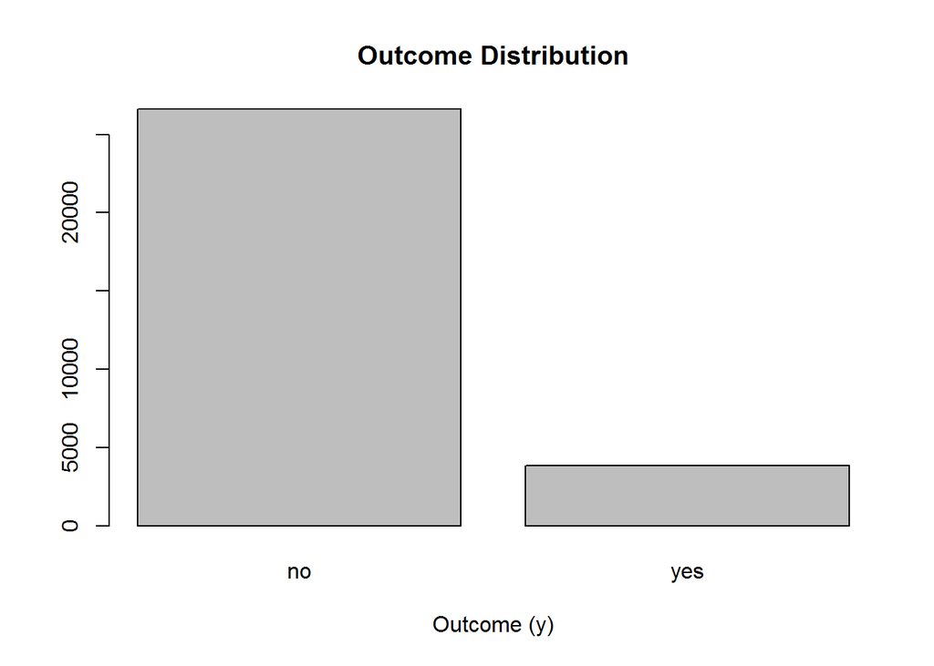

```r
barplot(table(bank$y),main="Outcome Distribution",
   xlab="Outcome (y)")
```

## Normality check for Euribor3m

##### Plot histogram

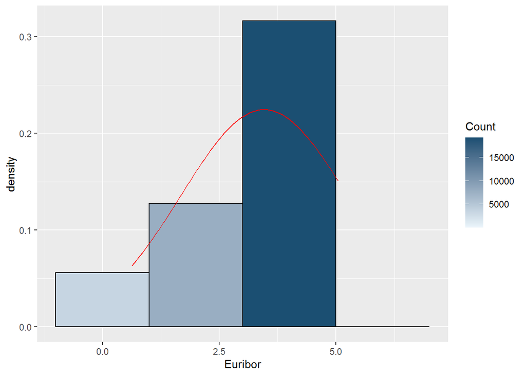

```r
#Analyse the normale distribution of Euribor3m
gg<-ggplot(data = bank,mapping = aes(x=bank$euribor3m))
#Change the label of the x axis
gg <- gg + labs(x="Euribor")

#manage binwidth and colours
gg <- gg + geom_histogram(binwidth=2, colour="black", aes(y=..density.., fill=..count..))
gg <- gg + scale_fill_gradient("Count", low="#EBF5FB", high="#1B4F72")

#adding a normal curve
gg <- gg + stat_function(fun=dnorm, color="red",args=list(mean=mean(bank$euribor3m, na.rm=TRUE), sd=sd(bank$euribor3m, na.rm=TRUE)))
gg
```

##### Plot Q-Q Plot

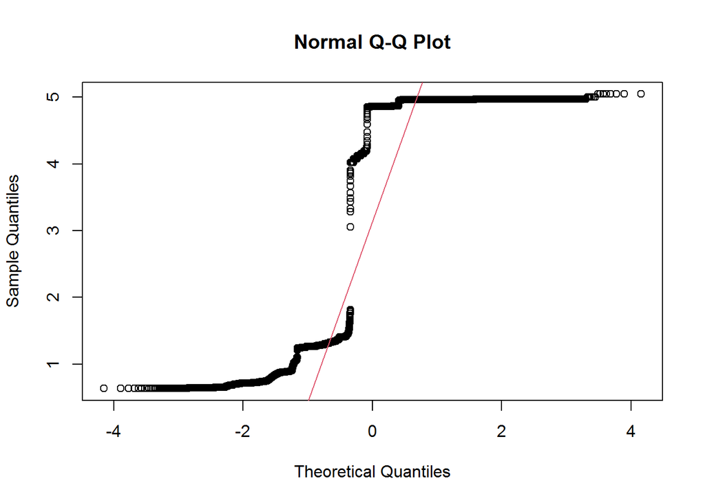

```r
#Create a qqplot
qqnorm(bank$euribor3m)
qqline(bank$euribor3m, col=2)
```

##### Summary Statistics

```r
stat.desc(bank$euribor3m, basic=F)
```

```
##       median         mean      SE.mean CI.mean.0.95          var      std.dev
##   4.85600000   3.45993761   0.01017840   0.01995009   3.15855027   1.77723107
##     coef.var
##   0.51365986
```

##### Skew and kurtosis Test:

The standardized scores(value/std. error) for Skewness and kurtosis between +/- 2 are considered acceptable in order to prove **normal univariate distribution**.

```r
#We can make our decision based on the value of the standardised score for skew and kurtosis
#We divide the skew statistic by the standard error to get the standardised score
#This will indicate if we have a problem
tpskew<-semTools::skew(bank$euribor3m)
tpskew[1]/tpskew[2]
```

```
## skew (g1)
## -37.42741
```

```r
tpkurt<-semTools::kurtosis(bank$euribor3m)
tpkurt[1]/tpkurt[2]
```

```
## Excess Kur (g2)
##       -58.16843
```

As the standardized scores of the Skew and kurtosis is outside of +/- 2 the impact need to be accessed. We need to check how much percentage of standardized score falling outside of 1.96. If it is less than 5%, then it is safe to say as a *Normal Distribution*.

As the number of sample is more than 80, we need to getback with the percentage of observation falling outside 3.29.

```r
#and by calculating the percentage of standardised scores for the variable itself that are outside our acceptable range
#This will tell us how big a problem we have
# Calculate the percentage of standardised scores that are greated than 1.96
# the perc function which is part of the FSA package which calculate the percentage that are within a range - you can look for greater than "gt", greater than or equal "geq", "gt", less than or equal "leq",  or less than "lt"),
# scale is a function that creates z scores, abs gets absolute value

ztpcoiss<- abs(scale(bank$euribor3m))

perc(as.numeric(ztpcoiss), 1.96, "gt")
```

```
## [1] 0
```

```r
perc(as.numeric(ztpcoiss), 3.29, "gt")
```

```
## [1] 0
```

### Report assessment of normality

Euribor3m score data was assessed for normality. Visual inspection of the histogram and QQ-Plot (see Figure 1 and Figure 2) identified some issues with skewness and kurtosis. The standardised score for kurtosis (-58.17) and the standardised score for skewness (-37.43) were outside the acceptable range using the criteria proposed by West, Finch and Curran (1996). However 100% of Euribor3m fall within the bounds of +/- 3.29, using the guidance of Field, Miles and Field (2013) the data can be considered to approximate a normal distribution (m=3.46, sd=1.78, n=30488).

## Normality check for Number of employees (nr.employed)

##### Plot histogram

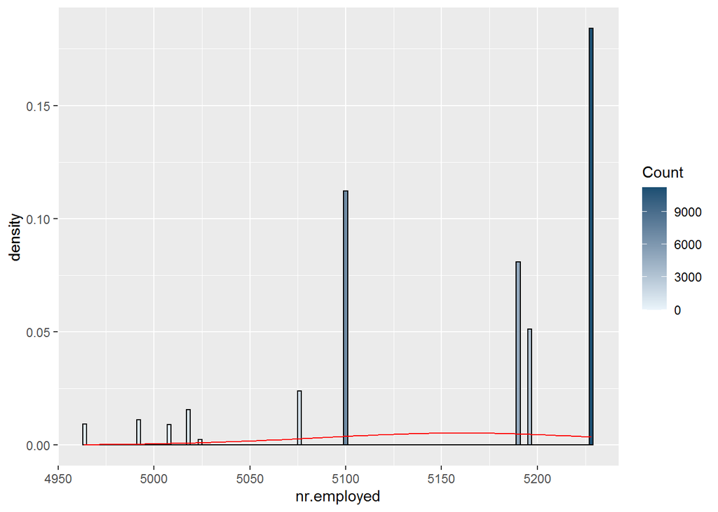

```r
#Analyse the normale distribution of nr.employed
gg<-ggplot(data = bank,mapping = aes(x=bank$nr.employed))
gg <- gg + labs(x="nr.employed")
gg <- gg + geom_histogram(binwidth=2, colour="black", aes(y=..density.., fill=..count..))
gg <- gg + scale_fill_gradient("Count", low="#EBF5FB", high="#1B4F72")
gg <- gg + stat_function(fun=dnorm, color="red",args=list(mean=mean(bank$nr.employed, na.rm=TRUE), sd=sd(bank$nr.employed, na.rm=TRUE)))
gg
```

##### Plot Q-Q Plot

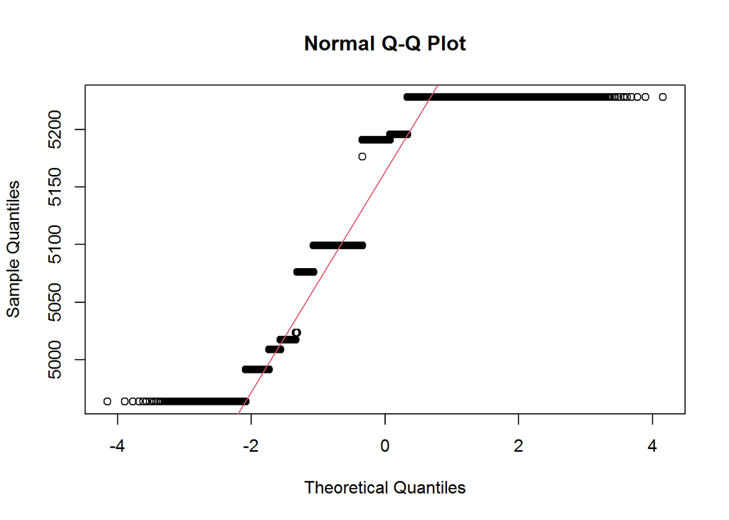

```r
#Create a qqplot
qqnorm(bank$nr.employed)
qqline(bank$nr.employed, col=2)
```

##### Summary Statistics

```r
#stat.desc is a function from pastecs - make sure you include the basic switch=F to ensure you don't get scienfitic notation
stat.desc(bank$nr.employed, basic=F)
```

```
##       median         mean      SE.mean CI.mean.0.95          var      std.dev
## 5.191000e+03 5.160813e+03 4.304385e-01 8.436775e-01 5.648735e+03 7.515806e+01
##     coef.var
## 1.456322e-02
```

##### Skew and kurtosis Test:

The standardized scores(value/std. error) for Skewness and kurtosis between +/- 2 are considered acceptable in order to prove **normal univariate distribution**.

```r
tpskew<-semTools::skew(bank$nr.employed)
tpskew[1]/tpskew[2]
```

```
## skew (g1)
## -63.71001
```

```r
tpkurt<-semTools::kurtosis(bank$nr.employed)
tpkurt[1]/tpkurt[2]
```

```
## Excess Kur (g2)
##       -12.53239
```

As the standardized scores of the Skew and kurtosis is outside of +/- 2 the impact need to be accessed. We need to check how much percentage of standardized score falling outside of 1.96. If it is less than 5%, then it is safe to say as a *Normal Distribution*.

As the number of sample is more than 80, we need to getback with the percentage of observation falling outside 3.29.

```r
ztpcoiss<- abs(scale(bank$nr.employed))

perc(as.numeric(ztpcoiss), 1.96, "gt")
```

```
## [1] 5.894122
```

```r
perc(as.numeric(ztpcoiss), 3.29, "gt")
```

```
## [1] 0
```

### Report assessment of normality

Number of employees data was assessed for normality. Visual inspection of the histogram and QQ-Plot (see Figure 1 and Figure 2) identified some issues with skewness and kurtosis. The standardized score for kurtosis (-12.53) and the standardized score for skewness (-63.71) were outside the acceptable range using the criteria proposed by West, Finch and Curran (1996). However 100% of Number of employees fall within the bounds of +/- 3.29, using the guidance of Field, Miles and Field (2013) the data can be considered to approximate a normal distribution (m=5160.81, sd=75.16, n=30488).

## Normality check for employment variation rate (emp.var.rate)

##### Plot histogram

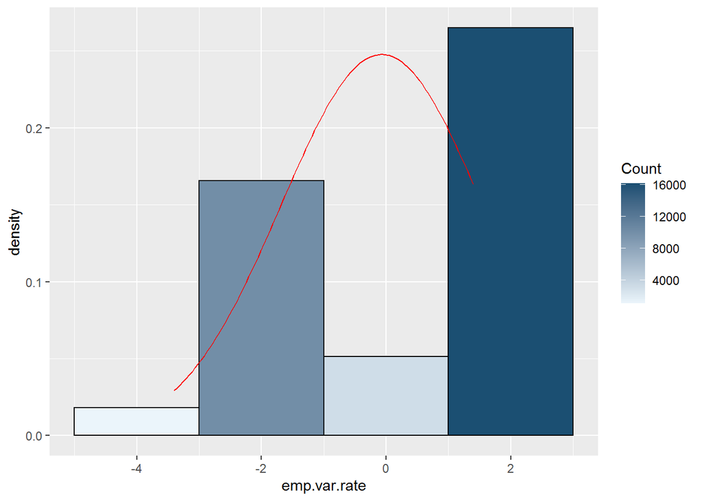

```r
#Analyse the normale distribution of emp.var.rate
gg<-ggplot(data = bank,mapping = aes(x=bank$emp.var.rate))
gg <- gg + labs(x="emp.var.rate")
gg <- gg + geom_histogram(binwidth=2, colour="black", aes(y=..density.., fill=..count..))
gg <- gg + scale_fill_gradient("Count", low="#EBF5FB", high="#1B4F72")
gg <- gg + stat_function(fun=dnorm, color="red",args=list(mean=mean(bank$emp.var.rate, na.rm=TRUE), sd=sd(bank$emp.var.rate, na.rm=TRUE)))
gg
```

##### Plot Q-Q Plot

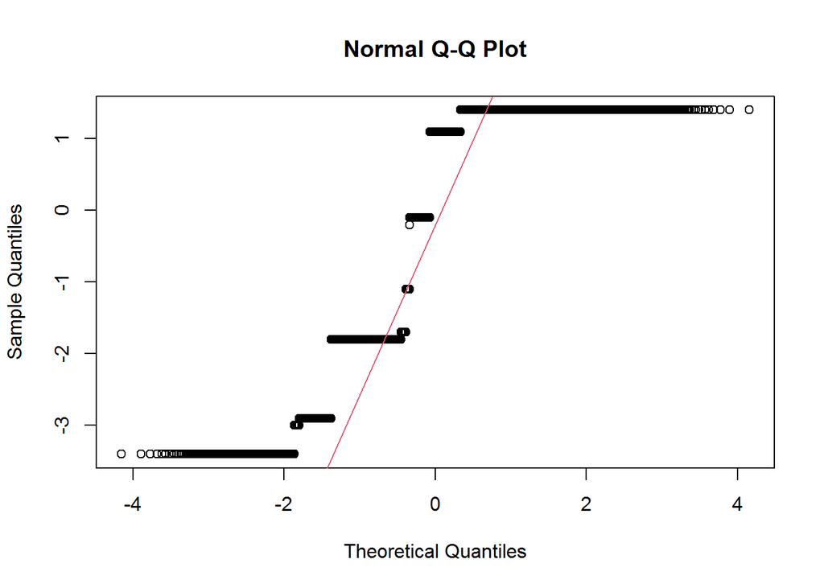

```r
qqnorm(bank$emp.var.rate)
qqline(bank$emp.var.rate, col=2) #show a line on theplot
```

##### Summary Statistics

```r
stat.desc(bank$emp.var.rate, basic=F)
```

```
##        median          mean       SE.mean  CI.mean.0.95           var
##   1.100000000  -0.071510102   0.009222935   0.018077338   2.593386482
##       std.dev      coef.var
##   1.610399479 -22.519887770
```

##### Skew and kurtosis Test:

The standardized scores(value/std. error) for Skewness and kurtosis between +/- 2 are considered acceptable in order to prove **normal univariate distribution**.

```r
tpskew<-semTools::skew(bank$emp.var.rate)
tpskew[1]/tpskew[2]
```

```
## skew (g1)
## -39.12893
```

```r
tpkurt<-semTools::kurtosis(bank$emp.var.rate)
tpkurt[1]/tpkurt[2]
```

```
## Excess Kur (g2)
##       -45.31947
```

As the standardized scores of the Skew and kurtosis is outside of +/- 2 the impact need to be accessed. We need to check how much percentage of standardized score falling outside of 1.96. If it is less than 5%, then it is safe to say as a *Normal Distribution*.

As the number of sample is more than 80, we need to getback with the percentage of observation falling outside 3.29.

```r
ztpcoiss<- abs(scale(bank$emp.var.rate))

perc(as.numeric(ztpcoiss), 1.96, "gt")
```

```
## [1] 3.11926
```

```r
perc(as.numeric(ztpcoiss), 3.29, "gt")
```

```
## [1] 0
```

### Report assessment of normality

Employment variation rate data was assessed for normality. Visual inspection of the histogram and QQ-Plot (see Figure 1 and Figure 2) identified some issues with skewness and kurtosis. The standardised score for kurtosis (-45.32) and the standardised score for skewness (-39.13) were outside the acceptable range using the criteria proposed by West, Finch and Curran (1996). However 100% of standardised emp.var.rate fall within the bounds of +/- 3.29, using the guidance of Field, Miles and Field (2013) the data can be considered to approximate a normal distribution (m=-0.07, sd=1.61, n=30488).

## Normality check for consumer price index (cons.price.idx)

##### Plot histogram

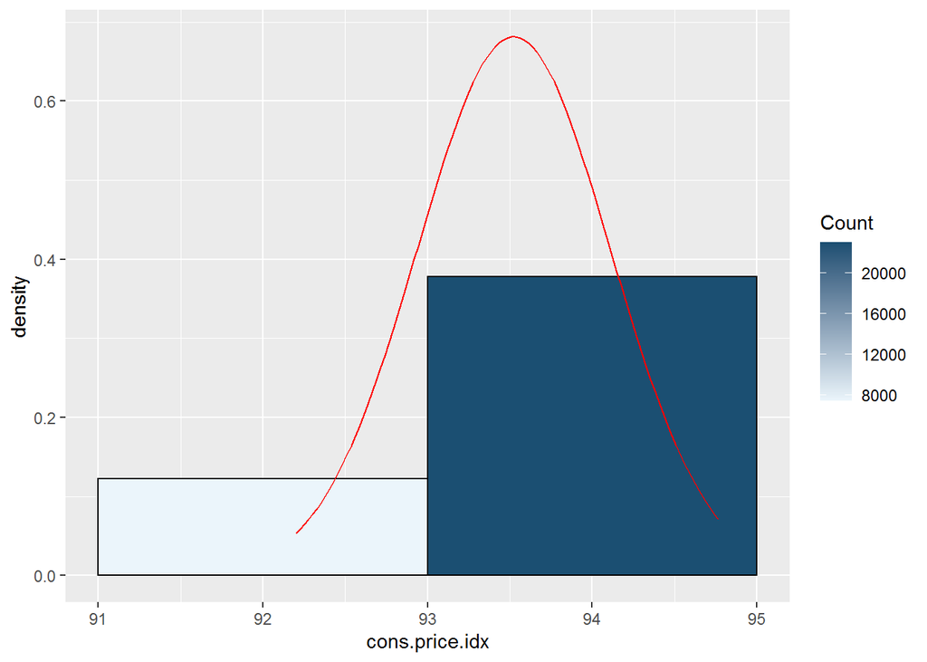

```r
#Analyse the normale distribution of consumer price index
gg<-ggplot(data = bank,mapping = aes(x=bank$cons.price.idx))
gg <- gg + labs(x="cons.price.idx")
gg <- gg + geom_histogram(binwidth=2, colour="black", aes(y=..density.., fill=..count..))
gg <- gg + scale_fill_gradient("Count", low="#EBF5FB", high="#1B4F72")
gg <- gg + stat_function(fun=dnorm, color="red",args=list(mean=mean(bank$cons.price.idx, na.rm=TRUE), sd=sd(bank$cons.price.idx, na.rm=TRUE)))
gg
```

##### Plot Q-Q Plot

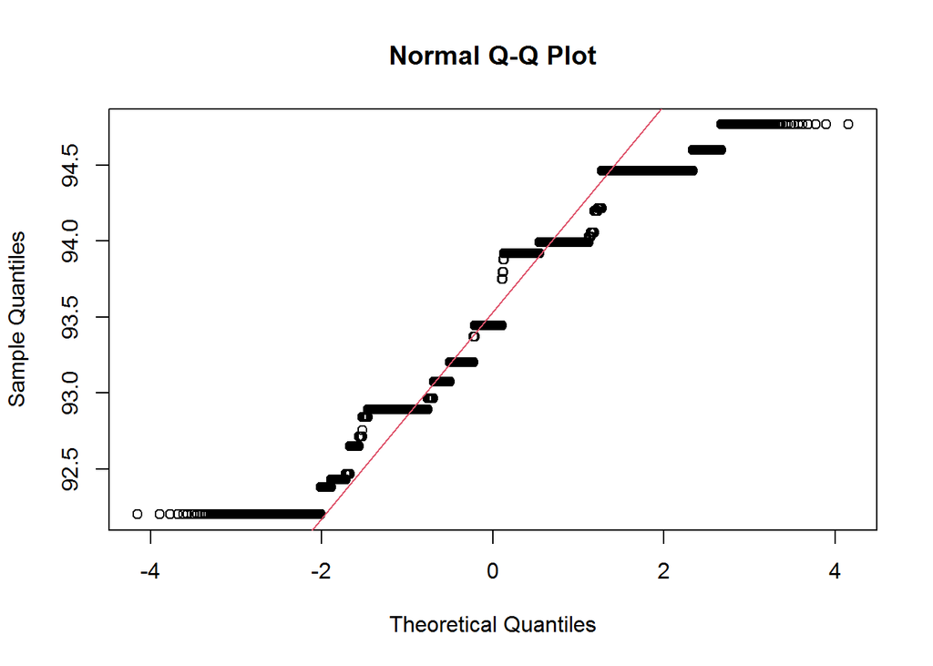

```r
qqnorm(bank$cons.price.idx)
qqline(bank$cons.price.idx, col=2)
```

##### Summary Statistics

```r
stat.desc(bank$cons.price.idx, basic=F)
```

```
##       median         mean      SE.mean CI.mean.0.95          var      std.dev
## 93.444000000 93.523311204  0.003352502  0.006571045  0.342662937  0.585374185
##     coef.var
##  0.006259126
```

##### Skew and kurtosis Test:

The standardized scores(value/std. error) for Skewness and kurtosis between +/- 2 are considered acceptable in order to prove **normal univariate distribution**.

```r
tpskew<-semTools::skew(bank$cons.price.idx)
tpskew[1]/tpskew[2]
```

```
## skew (g1)
## -8.463112
```

```r
tpkurt<-semTools::kurtosis(bank$cons.price.idx)
tpkurt[1]/tpkurt[2]
```

```
## Excess Kur (g2)
##       -30.76583
```

As the standardized scores of the Skew and kurtosis is outside of +/- 2 the impact need to be accessed. We need to check how much percentage of standardized score falling outside of 1.96. If it is less than 5%, then it is safe to say as a *Normal Distribution*.

As the number of sample is more than 80, we need to getback with the percentage of observation falling outside 3.29.

```r
ztpcoiss<- abs(scale(bank$cons.price.idx))

perc(as.numeric(ztpcoiss), 1.96, "gt")
```

```
## [1] 2.597743
```

```r
perc(as.numeric(ztpcoiss), 3.29, "gt")
```

```
## [1] 0
```

### Report assessment of normality

consumer price index data was assessed for normality. Visual inspection of the histogram and QQ-Plot (see Figure 1 and Figure 2) identified some issues with skewness and kurtosis. The standardised score for kurtosis (-30.77) and the standardised score for skewness (-8.46) were outside the acceptable range using the criteria proposed by West, Finch and Curran (1996). However 100% of standardised consumer price index fall within the bounds of +/- 3.29, using the guidance of Field, Miles and Field (2013) the data can be considered to approximate a normal distribution (m=93.52, sd=0.59, n=30488).

## Normality check for consumer confidence index (cons.conf.idx)

##### Plot histogram

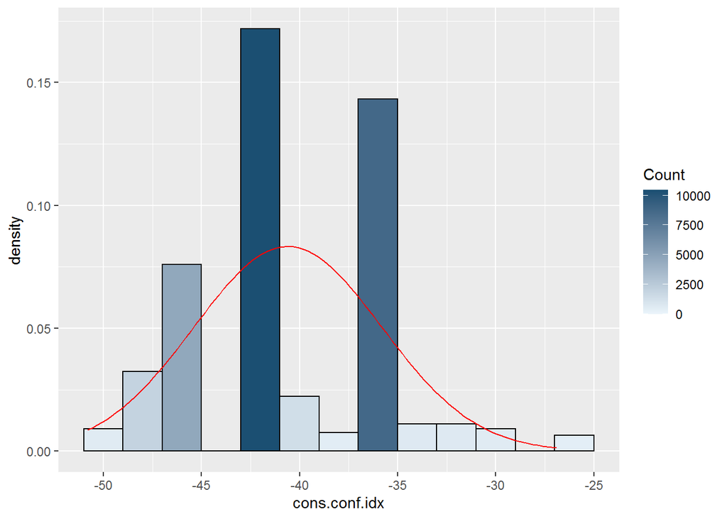

```r
gg<-ggplot(data = bank,mapping = aes(x=bank$cons.conf.idx))
gg <- gg + labs(x="cons.conf.idx")
gg <- gg + geom_histogram(binwidth=2, colour="black", aes(y=..density.., fill=..count..))
gg <- gg + scale_fill_gradient("Count", low="#EBF5FB", high="#1B4F72")
gg <- gg + stat_function(fun=dnorm, color="red",args=list(mean=mean(bank$cons.conf.idx, na.rm=TRUE), sd=sd(bank$cons.conf.idx, na.rm=TRUE)))
gg
```

##### Plot Q-Q Plot

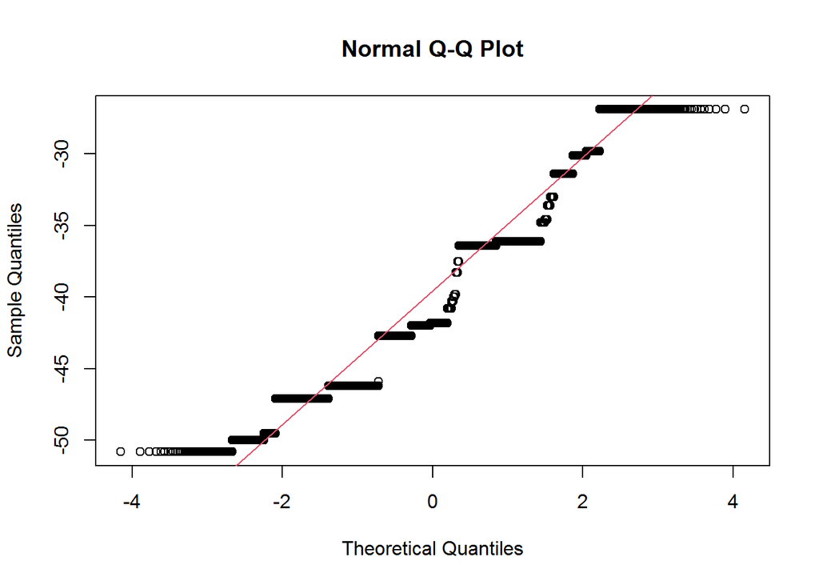

```r
qqnorm(bank$cons.conf.idx)
qqline(bank$cons.conf.idx, col=2)
```

##### Summary Statistics

```r
stat.desc(bank$cons.conf.idx, basic=F)
```

```
##       median         mean      SE.mean CI.mean.0.95          var      std.dev
## -41.80000000 -40.60226319   0.02742856   0.05376112  22.93690963   4.78924938
##     coef.var
##  -0.11795523
```

##### Skew and kurtosis Test:

The standardized scores(value/std. error) for Skewness and kurtosis between +/- 2 are considered acceptable in order to prove **normal univariate distribution**.

```r
tpskew<-semTools::skew(bank$cons.conf.idx)
tpskew[1]/tpskew[2]
```

```
## skew (g1)
##  26.65624
```

```r
tpkurt<-semTools::kurtosis(bank$cons.conf.idx)
tpkurt[1]/tpkurt[2]
```

```
## Excess Kur (g2)
##       -11.53008
```

As the standardized scores of the Skew and kurtosis is outside of +/- 2 the impact need to be accessed. We need to check how much percentage of standardized score falling outside of 1.96. If it is less than 5%, then it is safe to say as a *Normal Distribution*.

As the number of sample is more than 80, we need to getback with the percentage of observation falling outside 3.29.

```r
ztpcoiss<- abs(scale(bank$cons.conf.idx))

perc(as.numeric(ztpcoiss), 1.96, "gt")
```

```
## [1] 4.355812
```

```r
perc(as.numeric(ztpcoiss), 3.29, "gt")
```

```
## [1] 0
```

### Report assessment of normality

cons.conf.idx score data was assessed for normality. Visual inspection of the histogram and QQ-Plot (see Figure 1 and Figure 2) identified some issues with skewness and kurtosis. The standardised score for kurtosis (-11.53) and the standardised score for skewness (26.66) were outside the acceptable range using the criteria proposed by West, Finch and Curran (1996). However 100% of standardised cons.conf.idx fall within the bounds of +/- 3.29, using the guidance of Field, Miles and Field (2013) the data can be considered to approximate a normal distribution (m=-40.6, sd=4.79, n=30488).

# Correlation check for Social and economic attributes

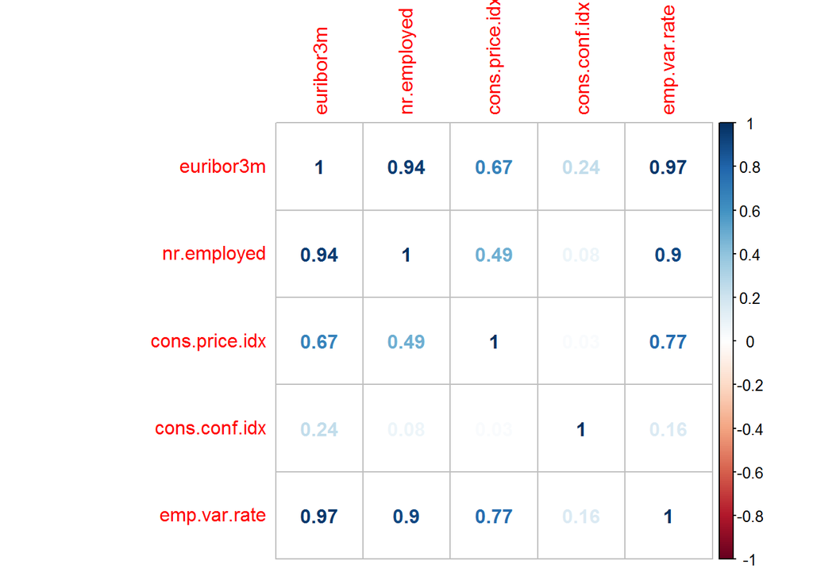

```r
secor = cor(bank[,c('euribor3m','nr.employed','cons.price.idx','cons.conf.idx','emp.var.rate')], method = c("pearson"))
corrplot::corrplot(secor, method = "number")
corrplot::corrplot(secor, method = "number")
```

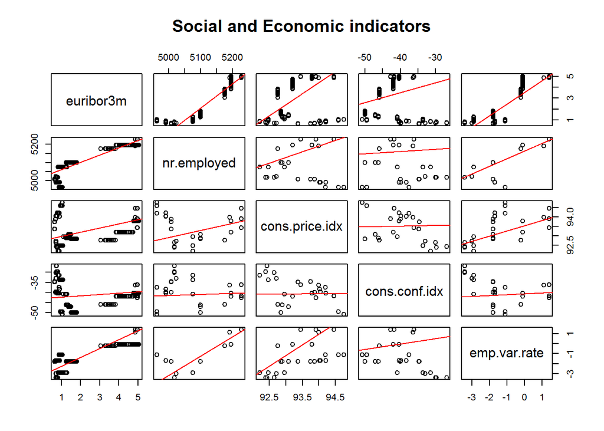

```r
library(car)
panel.lm <- function (x, y,  pch = par("pch"), col.lm = "red",  ...) {
  ymin <- min(y)
  ymax <- max(y)
  xmin <- min(x)
  xmax <- max(x)
  ylim <- c(min(ymin,xmin),max(ymax,xmax))
  xlim <- ylim
  points(x, y, pch = pch,ylim = ylim, xlim= xlim,...)
  ok <- is.finite(x) & is.finite(y)
  if (any(ok))
    abline(lm(y[ok]~ x[ok]),
           col = col.lm, ...)
}
pairs(~euribor3m+nr.employed+cons.price.idx+cons.conf.idx+emp.var.rate, data=bank,main="Social and Economic indicators", lower.panel = panel.lm, upper.panel = panel.lm)
```

#### Conducting Correlation Tests - Pearson for Social and economic attributes

```r
#Pearson Correlation
stats::cor.test(bank$nr.employed, bank$euribor3m, method='pearson')
```

```
##
##  Pearson's product-moment correlation
##
## data:  bank$nr.employed and bank$euribor3m
## t = 503.84, df = 30486, p-value < 2.2e-16
## alternative hypothesis: true correlation is not equal to 0
## 95 percent confidence interval:
##  0.9436549 0.9460622
## sample estimates:
##       cor
## 0.9448713
```

```r
stats::cor.test(bank$nr.employed, bank$cons.price.idx, method='pearson')
```

```
##
##  Pearson's product-moment correlation
##
## data:  bank$nr.employed and bank$cons.price.idx
## t = 97.848, df = 30486, p-value < 2.2e-16
## alternative hypothesis: true correlation is not equal to 0
## 95 percent confidence interval:
##  0.4802814 0.4973665
## sample estimates:
##       cor
## 0.4888709
```

```r
stats::cor.test(bank$nr.employed, bank$cons.conf.idx, method='pearson')
```

```
##
##  Pearson's product-moment correlation
##
## data:  bank$nr.employed and bank$cons.conf.idx
## t = 13.182, df = 30486, p-value < 2.2e-16
## alternative hypothesis: true correlation is not equal to 0
## 95 percent confidence interval:
##  0.06411187 0.08643468
## sample estimates:
##        cor
## 0.07528271
```

```r
stats::cor.test(bank$nr.employed, bank$emp.var.rate, method='pearson')
```

```
##
##  Pearson's product-moment correlation
##
## data:  bank$nr.employed and bank$emp.var.rate
## t = 361.33, df = 30486, p-value < 2.2e-16
## alternative hypothesis: true correlation is not equal to 0
## 95 percent confidence interval:
##  0.8982437 0.9024939
## sample estimates:
##       cor
## 0.9003902
```

## Model-1 | nr.employed as predictor

```r
logmodel1 <- glm(y_new ~ nr.employed , data = bank, na.action = na.exclude, family = binomial(link=logit))
sum<-summary(logmodel1)
sum
```

```
##
## Call:
## glm(formula = y_new ~ nr.employed, family = binomial(link = logit),
##     data = bank, na.action = na.exclude)
##
## Deviance Residuals:
##     Min       1Q   Median       3Q      Max
## -1.3038  -0.6373  -0.3497  -0.2842   2.5413
##
## Coefficients:
##               Estimate Std. Error z value Pr(>|z|)
## (Intercept) 65.6204771  1.1881554   55.23   <2e-16 ***
## nr.employed -0.0131614  0.0002326  -56.58   <2e-16 ***
## ---
## Signif. codes:  0 '***' 0.001 '**' 0.01 '*' 0.05 '.' 0.1 ' ' 1
##
## (Dispersion parameter for binomial family taken to be 1)
##
##     Null deviance: 23160  on 30487  degrees of freedom
## Residual deviance: 19528  on 30486  degrees of freedom
## AIC: 19532
##
## Number of Fisher Scoring iterations: 5
```

```r
m1aic<-round(sum$aic,0)
m1aic<-as.integer(m1aic)
```

The AIC of the model is: 19532

```r
#Chi-square plus significance
rtest<-lmtest::lrtest(logmodel1)
rtest
```

|  | #Df | LogLik | Df | Chisq | Pr(>Chisq) |
| --- | --- | --- | --- | --- | --- |
| 1 | 2 | -9764.028 | NA | NA | NA |
| 2 | 1 | -11580.028 | -1 | 3632.001 | 0 |

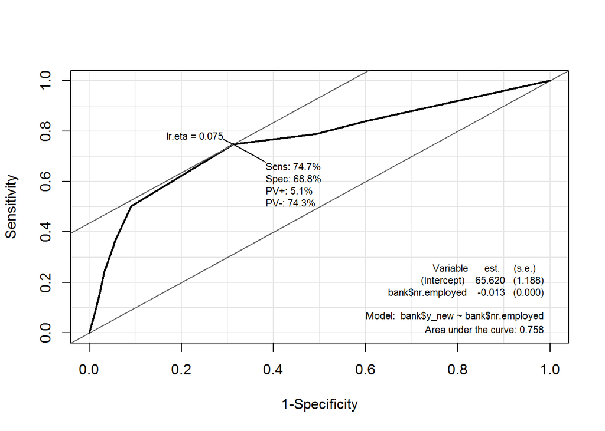

```r
#Output the sensitivity, specificity, and ROC plot
Epi::ROC(form=bank$y_new ~ bank$nr.employed, plot="ROC")
p<-Epi::ROC(form=bank$y_new ~ bank$nr.employed, plot="ROC")
```

```r
m1auc<-round(p$AUC,3)

#Pseudo Rsquared
m1csr2<-DescTools::PseudoR2(logmodel1, which="CoxSnell")
m1csr2
```

```
##  CoxSnell
## 0.1123066
```

```r
m1knr2<-DescTools::PseudoR2(logmodel1, which="Nagelkerke")
m1knr2
```

```
## Nagelkerke
##  0.2110362
```

The AUC of the model is: 0.758

The pseudo R square indicate that between 11.23% and 21.1% of the variability of responses to whether the customer opts for the term deposit or not.

```r
#Summary of the model with co-efficients
stargazer(logmodel1, type="text")
```

```
##
## =============================================
##                       Dependent variable:
##                   ---------------------------
##                              y_new
## ---------------------------------------------
## nr.employed                -0.013***
##                            (0.0002)
##
## Constant                   65.620***
##                             (1.188)
##
## ---------------------------------------------
## Observations                30,488
## Log Likelihood            -9,764.028
## Akaike Inf. Crit.         19,532.060
## =============================================
## Note:             *p<0.1; **p<0.05; ***p<0.01
```

nr.employed Predictor selected.

## Model-2 | nr.employed and cons.conf.idx as predictor

```r
logmodel2 <- glm(y_new ~ nr.employed+cons.conf.idx , data = bank, na.action = na.exclude, family = binomial(link=logit))

#Full summary of the model
sum<-summary(logmodel2)
sum
```

```
##
## Call:
## glm(formula = y_new ~ nr.employed + cons.conf.idx, family = binomial(link = logit),
##     data = bank, na.action = na.exclude)
##
## Deviance Residuals:
##     Min       1Q   Median       3Q      Max
## -1.3245  -0.5913  -0.3469  -0.2805   2.5516
##
## Coefficients:
##                 Estimate Std. Error z value Pr(>|z|)
## (Intercept)   65.5557748  1.1712981  55.968  < 2e-16 ***
## nr.employed   -0.0129501  0.0002307 -56.136  < 2e-16 ***
## cons.conf.idx  0.0249949  0.0031209   8.009 1.16e-15 ***
## ---
## Signif. codes:  0 '***' 0.001 '**' 0.01 '*' 0.05 '.' 0.1 ' ' 1
##
## (Dispersion parameter for binomial family taken to be 1)
##
##     Null deviance: 23160  on 30487  degrees of freedom
## Residual deviance: 19464  on 30485  degrees of freedom
## AIC: 19470
##
## Number of Fisher Scoring iterations: 5
```

```r
m2aic<-as.integer(round(sum$aic,0))
```

The AIC of the model is: 19470

```r
#Chi-square plus significance
lmtest::lrtest(logmodel1,logmodel2)
```

|  | #Df | LogLik | Df | Chisq | Pr(>Chisq) |
| --- | --- | --- | --- | --- | --- |
| 1 | 2 | -9764.028 | NA | NA | NA |
| 2 | 3 | -9731.911 | 1 | 64.2332 | 1.105304e-15 |

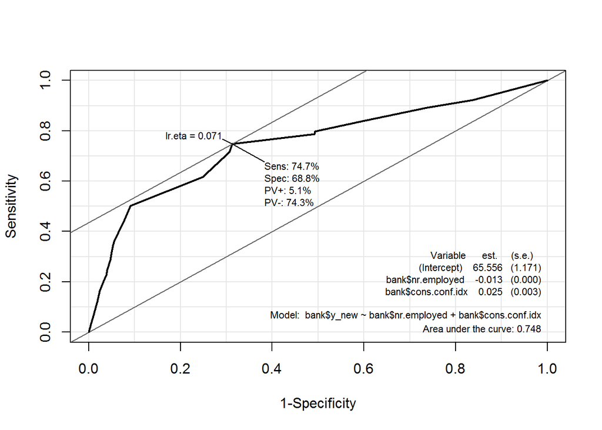

```r
Epi::ROC(form=bank$y_new ~ bank$nr.employed+bank$cons.conf.idx, plot="ROC")
p<-Epi::ROC(form=bank$y_new ~ bank$nr.employed+bank$cons.conf.idx, plot="ROC")
```

```r
m2auc<-round(p$AUC,3)

m2csr2<-DescTools::PseudoR2(logmodel2, which="CoxSnell")
m2csr2
```

```
##  CoxSnell
## 0.1141749
```

```r
m2knr2<-DescTools::PseudoR2(logmodel2, which="Nagelkerke")
m2knr2
```

```
## Nagelkerke
##  0.2145468
```

The AUC of the model is: 0.748

The pseudo R square indicate that between 11.42% and 21.45% of the variability of responses to whether the customer opts for the term deposit or not.

```r
#Summary of the model with co-efficients
stargazer(logmodel2, type="text")
```

```
##
## =============================================
##                       Dependent variable:
##                   ---------------------------
##                              y_new
## ---------------------------------------------
## nr.employed                -0.013***
##                            (0.0002)
##
## cons.conf.idx              0.025***
##                             (0.003)
##
## Constant                   65.556***
##                             (1.171)
##
## ---------------------------------------------
## Observations                30,488
## Log Likelihood            -9,731.911
## Akaike Inf. Crit.         19,469.820
## =============================================
## Note:             *p<0.1; **p<0.05; ***p<0.01
```

cons.conf.idx predictor rejected as AUC dropped.

## Model-3 | nr.employed and age as predictor

```r
logmodel3 <- glm(y_new ~ nr.employed+age , data = bank, na.action = na.exclude, family = binomial(link=logit))
summary(logmodel3)
```

```
##
## Call:
## glm(formula = y_new ~ nr.employed + age, family = binomial(link = logit),
##     data = bank, na.action = na.exclude)
##
## Deviance Residuals:
##     Min       1Q   Median       3Q      Max
## -1.3942  -0.6224  -0.3457  -0.2812   2.5694
##
## Coefficients:
##               Estimate Std. Error z value Pr(>|z|)
## (Intercept) 65.1149863  1.1998346  54.270  < 2e-16 ***
## nr.employed -0.0130967  0.0002334 -56.101  < 2e-16 ***
## age          0.0044142  0.0015622   2.826  0.00472 **
## ---
## Signif. codes:  0 '***' 0.001 '**' 0.01 '*' 0.05 '.' 0.1 ' ' 1
##
## (Dispersion parameter for binomial family taken to be 1)
##
##     Null deviance: 23160  on 30487  degrees of freedom
## Residual deviance: 19520  on 30485  degrees of freedom
## AIC: 19526
##
## Number of Fisher Scoring iterations: 5
```

```r
#Chi-square plus significance
lmtest::lrtest(logmodel1,logmodel3)
```

|  | #Df | LogLik | Df | Chisq | Pr(>Chisq) |
| --- | --- | --- | --- | --- | --- |
| 1 | 2 | -9764.028 | NA | NA | NA |
| 2 | 3 | -9760.054 | 1 | 7.948094 | 0.004813805 |

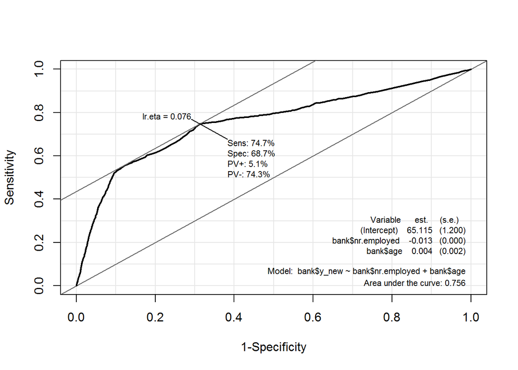

```r
#Output the sensitivity, specificity, and ROC plot
Epi::ROC(form=bank$y_new ~ bank$nr.employed+bank$age, plot="ROC")
p<-Epi::ROC(form=bank$y_new ~ bank$nr.employed+bank$age, plot="ROC")
```

```r
m3auc<-round(p$AUC,3)

#Pseudo Rsquared
m3csr2<-DescTools::PseudoR2(logmodel3, which="CoxSnell")
m3csr2
```

```
## CoxSnell
## 0.112538
```

```r
m3knr2<-DescTools::PseudoR2(logmodel3, which="Nagelkerke")
m3knr2
```

```
## Nagelkerke
##   0.211471
```

The AUC of the model is: 0.756

The pseudo R square indicate that between 11.25% and 21.15% of the variability of responses to whether the customer opts for the term deposit or not.

```r
#Summary of the model with co-efficients
stargazer(logmodel3, type="text")
```

```
##
## =============================================
##                       Dependent variable:
##                   ---------------------------
##                              y_new
## ---------------------------------------------
## nr.employed                -0.013***
##                            (0.0002)
##
## age                        0.004***
##                             (0.002)
##
## Constant                   65.115***
##                             (1.200)
##
## ---------------------------------------------
## Observations                30,488
## Log Likelihood            -9,760.054
## Akaike Inf. Crit.         19,526.110
## =============================================
## Note:             *p<0.1; **p<0.05; ***p<0.01
```

Age Predictor rejected as AUC dropped and very small improvement in AIC.

## Model-4 | nr.employed and job as predictor

```r
logmodel4 <- glm(y_new ~ nr.employed+job , data = bank, na.action = na.exclude, family = binomial(link=logit))
summary(logmodel4)
```

```
##
## Call:
## glm(formula = y_new ~ nr.employed + job, family = binomial(link = logit),
##     data = bank, na.action = na.exclude)
##
## Deviance Residuals:
##     Min       1Q   Median       3Q      Max
## -1.4586  -0.5386  -0.3095  -0.2971   2.6503
##
## Coefficients:
##                    Estimate Std. Error z value Pr(>|z|)
## (Intercept)      62.8088049  1.2142255  51.727  < 2e-16 ***
## nr.employed      -0.0125943  0.0002377 -52.986  < 2e-16 ***
## jobblue-collar   -0.4462391  0.0609280  -7.324 2.41e-13 ***
## jobentrepreneur  -0.2280010  0.1144760  -1.992 0.046405 *
## jobhousemaid     -0.0250256  0.1300772  -0.192 0.847436
## jobmanagement    -0.0626149  0.0754352  -0.830 0.406511
## jobretired        0.3194570  0.0781297   4.089 4.34e-05 ***
## jobself-employed -0.0792177  0.1045009  -0.758 0.448417
## jobservices      -0.3697719  0.0761993  -4.853 1.22e-06 ***
## jobstudent        0.3447877  0.0995447   3.464 0.000533 ***
## jobtechnician    -0.0391157  0.0563307  -0.694 0.487435
## jobunemployed     0.0291140  0.1126199   0.259 0.796009
## ---
## Signif. codes:  0 '***' 0.001 '**' 0.01 '*' 0.05 '.' 0.1 ' ' 1
##
## (Dispersion parameter for binomial family taken to be 1)
##
##     Null deviance: 23160  on 30487  degrees of freedom
## Residual deviance: 19397  on 30476  degrees of freedom
## AIC: 19421
##
## Number of Fisher Scoring iterations: 5
```

```r
#Chi-square plus significance
lmtest::lrtest(logmodel1,logmodel4)
```

|  | #Df | LogLik | Df | Chisq | Pr(>Chisq) |
| --- | --- | --- | --- | --- | --- |
| 1 | 2 | -9764.028 | NA | NA | NA |
| 2 | 12 | -9698.336 | 10 | 131.3833 | 2.438659e-23 |

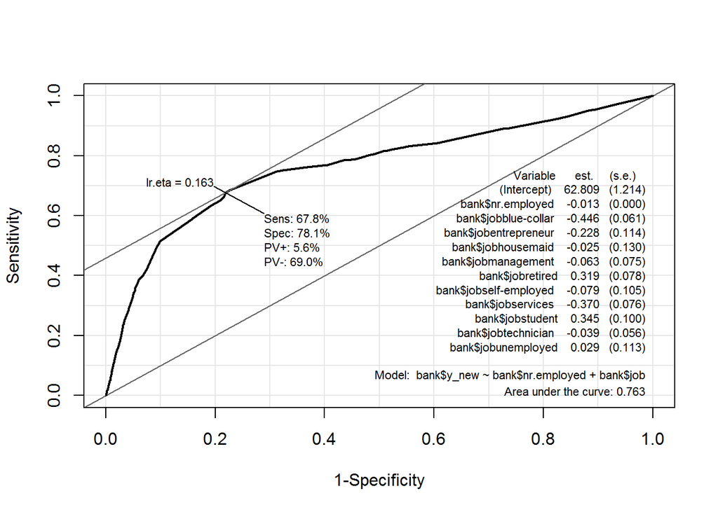

```r
#Output the sensitivity, specificity, and ROC plot
Epi::ROC(form=bank$y_new ~ bank$nr.employed+bank$job, plot="ROC")
p<-Epi::ROC(form=bank$y_new ~ bank$nr.employed+bank$job, plot="ROC")
```

```r
m4auc<-round(p$AUC,3)

#Pseudo Rsquared
m4csr2<-DescTools::PseudoR2(logmodel4, which="CoxSnell")
m4csr2
```

```
##  CoxSnell
## 0.1161238
```

```r
m4knr2<-DescTools::PseudoR2(logmodel4, which="Nagelkerke")
m4knr2
```

```
## Nagelkerke
##   0.218209
```

The AUC of the model is: 0.763

The pseudo R square indicate that between 11.61% and 21.82% of the variability of responses to whether the customer opts for the term deposit or not.

```r
#Summary of the model with co-efficients
stargazer(logmodel4, type="text")
```

```
##
## =============================================
##                       Dependent variable:
##                   ---------------------------
##                              y_new
## ---------------------------------------------
## nr.employed                -0.013***
##                            (0.0002)
##
## jobblue-collar             -0.446***
##                             (0.061)
##
## jobentrepreneur            -0.228**
##                             (0.114)
##
## jobhousemaid                -0.025
##                             (0.130)
##
## jobmanagement               -0.063
##                             (0.075)
##
## jobretired                 0.319***
##                             (0.078)
##
## jobself-employed            -0.079
##                             (0.105)
##
## jobservices                -0.370***
##                             (0.076)
##
## jobstudent                 0.345***
##                             (0.100)
##
## jobtechnician               -0.039
##                             (0.056)
##
## jobunemployed                0.029
##                             (0.113)
##
## Constant                   62.809***
##                             (1.214)
##
## ---------------------------------------------
## Observations                30,488
## Log Likelihood            -9,698.336
## Akaike Inf. Crit.         19,420.670
## =============================================
## Note:             *p<0.1; **p<0.05; ***p<0.01
```

Job Predictor selected. Rise in AUC and decrease in AIC.

## Model-5 | nr.employed, job and marital as predictor

```r
logmodel5 <- glm(y_new ~ nr.employed+job+marital , data = bank, na.action = na.exclude, family = binomial(link=logit))
summary(logmodel5)
```

```
##
## Call:
## glm(formula = y_new ~ nr.employed + job + marital, family = binomial(link = logit),
##     data = bank, na.action = na.exclude)
##
## Deviance Residuals:
##     Min       1Q   Median       3Q      Max
## -1.4755  -0.5357  -0.3127  -0.2929   2.6707
##
## Coefficients:
##                    Estimate Std. Error z value Pr(>|z|)
## (Intercept)      62.5921767  1.2203948  51.288  < 2e-16 ***
## nr.employed      -0.0125650  0.0002382 -52.743  < 2e-16 ***
## jobblue-collar   -0.4387232  0.0614632  -7.138 9.47e-13 ***
## jobentrepreneur  -0.2132162  0.1149220  -1.855  0.06355 .
## jobhousemaid     -0.0080670  0.1305066  -0.062  0.95071
## jobmanagement    -0.0509693  0.0759503  -0.671  0.50216
## jobretired        0.3480828  0.0799107   4.356 1.33e-05 ***
## jobself-employed -0.0762549  0.1045550  -0.729  0.46580
## jobservices      -0.3656649  0.0762680  -4.794 1.63e-06 ***
## jobstudent        0.3106417  0.1018145   3.051  0.00228 **
## jobtechnician    -0.0382569  0.0563530  -0.679  0.49721
## jobunemployed     0.0340178  0.1127024   0.302  0.76278
## maritalmarried    0.0481982  0.0627635   0.768  0.44253
## maritalsingle     0.1056446  0.0672411   1.571  0.11615
## ---
## Signif. codes:  0 '***' 0.001 '**' 0.01 '*' 0.05 '.' 0.1 ' ' 1
##
## (Dispersion parameter for binomial family taken to be 1)
##
##     Null deviance: 23160  on 30487  degrees of freedom
## Residual deviance: 19394  on 30474  degrees of freedom
## AIC: 19422
##
## Number of Fisher Scoring iterations: 5
```

```r
lmtest::lrtest(logmodel4,logmodel5)
```

|  | #Df | LogLik | Df | Chisq | Pr(>Chisq) |
| --- | --- | --- | --- | --- | --- |
| 1 | 12 | -9698.336 | NA | NA | NA |
| 2 | 14 | -9696.828 | 2 | 3.015856 | 0.2213682 |

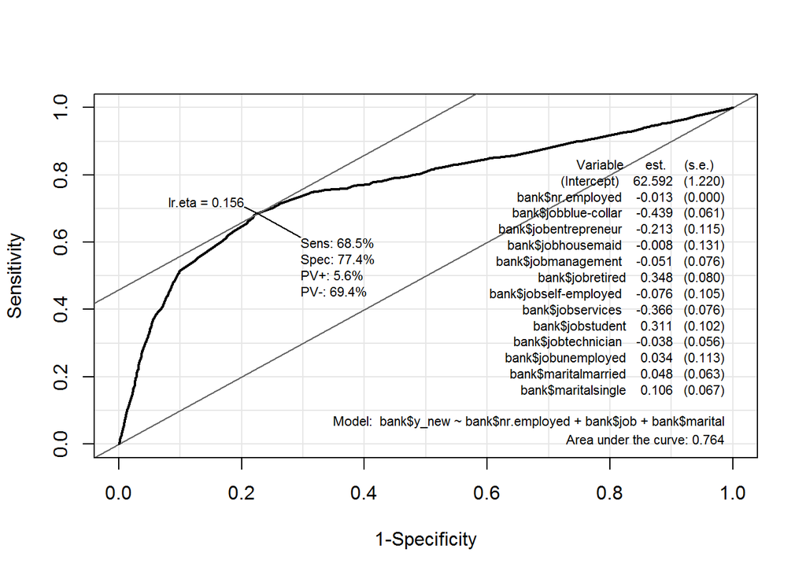

```r
Epi::ROC(form=bank$y_new ~ bank$nr.employed+bank$job+bank$marital, plot="ROC")
p<-Epi::ROC(form=bank$y_new ~ bank$nr.employed+bank$job+bank$marital, plot="ROC")
```

```r
m5auc<-round(p$AUC,3)
m5csr2<-DescTools::PseudoR2(logmodel5, which="CoxSnell")
m5csr2
```

```
##  CoxSnell
## 0.1162112
```

```r
m5knr2<-DescTools::PseudoR2(logmodel5, which="Nagelkerke")
m5knr2
```

```
## Nagelkerke
##  0.2183733
```

The AUC of the model is: 0.764

The pseudo R square indicate that between 11.62% and 21.84% of the variability of responses to whether the customer opts for the term deposit or not.

```r
stargazer(logmodel5, type="text")
```

```
##
## =============================================
##                       Dependent variable:
##                   ---------------------------
##                              y_new
## ---------------------------------------------
## nr.employed                -0.013***
##                            (0.0002)
##
## jobblue-collar             -0.439***
##                             (0.061)
##
## jobentrepreneur             -0.213*
##                             (0.115)
##
## jobhousemaid                -0.008
##                             (0.131)
##
## jobmanagement               -0.051
##                             (0.076)
##
## jobretired                 0.348***
##                             (0.080)
##
## jobself-employed            -0.076
##                             (0.105)
##
## jobservices                -0.366***
##                             (0.076)
##
## jobstudent                 0.311***
##                             (0.102)
##
## jobtechnician               -0.038
##                             (0.056)
##
## jobunemployed                0.034
##                             (0.113)
##
## maritalmarried               0.048
##                             (0.063)
##
## maritalsingle                0.106
##                             (0.067)
##
## Constant                   62.592***
##                             (1.220)
##
## ---------------------------------------------
## Observations                30,488
## Log Likelihood            -9,696.828
## Akaike Inf. Crit.         19,421.660
## =============================================
## Note:             *p<0.1; **p<0.05; ***p<0.01
```

marital predictor rejected as Probability >0.05 and increase in AIC.

## Model-6 | nr.employed, job and education as predictor

```r
logmodel6 <- glm(y_new ~ nr.employed+job+education , data = bank, na.action = na.exclude, family = binomial(link=logit))
summary(logmodel6)
```

```
##
## Call:
## glm(formula = y_new ~ nr.employed + job + education, family = binomial(link = logit),
##     data = bank, na.action = na.exclude)
##
## Deviance Residuals:
##     Min       1Q   Median       3Q      Max
## -1.5284  -0.5224  -0.3188  -0.2911   2.6722
##
## Coefficients:
##                                Estimate Std. Error z value Pr(>|z|)
## (Intercept)                  62.4554154  1.2167039  51.332  < 2e-16 ***
## nr.employed                  -0.0125504  0.0002378 -52.776  < 2e-16 ***
## jobblue-collar               -0.3073602  0.0751883  -4.088 4.35e-05 ***
## jobentrepreneur              -0.2033210  0.1155096  -1.760 0.078372 .
## jobhousemaid                  0.0589391  0.1359392   0.434 0.664601
## jobmanagement                -0.0996603  0.0764927  -1.303 0.192618
## jobretired                    0.3948408  0.0857124   4.607 4.09e-06 ***
## jobself-employed             -0.0924231  0.1054346  -0.877 0.380709
## jobservices                  -0.2728291  0.0802797  -3.398 0.000678 ***
## jobstudent                    0.4300905  0.1013326   4.244 2.19e-05 ***
## jobtechnician                -0.0038538  0.0637603  -0.060 0.951804
## jobunemployed                 0.0971143  0.1140197   0.852 0.394362
## educationbasic.6y             0.0646014  0.1192796   0.542 0.588097
## educationbasic.9y            -0.0752142  0.0920510  -0.817 0.413875
## educationhigh.school          0.0232059  0.0872844   0.266 0.790343
## educationilliterate           1.3355926  0.7545368   1.770 0.076713 .
## educationprofessional.course  0.0623303  0.0951156   0.655 0.512268
## educationuniversity.degree    0.2051761  0.0866963   2.367 0.017952 *
## ---
## Signif. codes:  0 '***' 0.001 '**' 0.01 '*' 0.05 '.' 0.1 ' ' 1
##
## (Dispersion parameter for binomial family taken to be 1)
##
##     Null deviance: 23160  on 30487  degrees of freedom
## Residual deviance: 19374  on 30470  degrees of freedom
## AIC: 19410
##
## Number of Fisher Scoring iterations: 5
```

```r
lmtest::lrtest(logmodel4,logmodel6)
```

|  | #Df | LogLik | Df | Chisq | Pr(>Chisq) |
| --- | --- | --- | --- | --- | --- |
| 1 | 12 | -9698.336 | NA | NA | NA |
| 2 | 18 | -9687.014 | 6 | 22.64359 | 0.0009250725 |

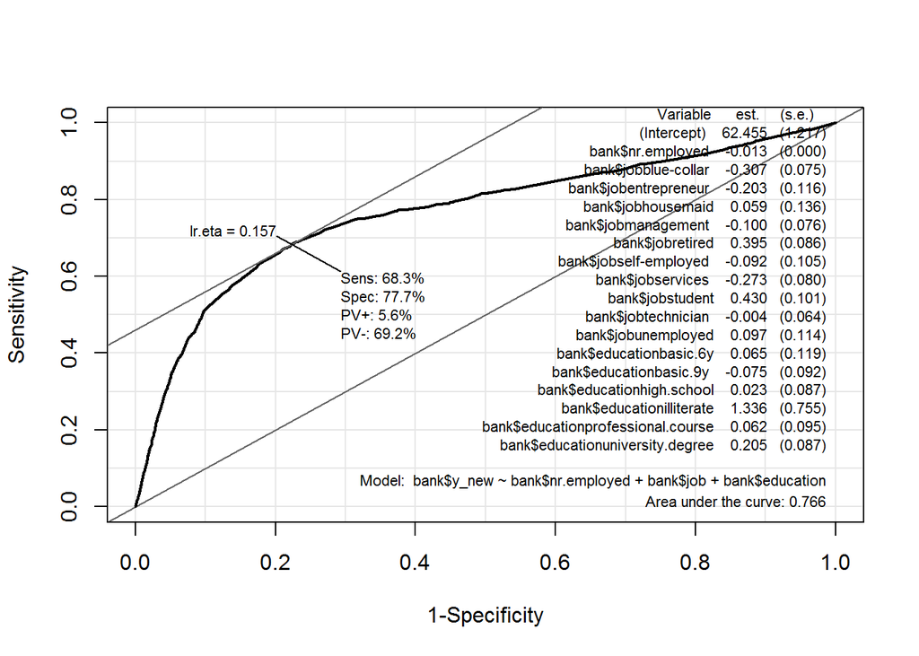

```r
#Output the sensitivity, specificity, and ROC plot
Epi::ROC(form=bank$y_new ~ bank$nr.employed+bank$job+bank$education, plot="ROC")
p<-Epi::ROC(form=bank$y_new ~ bank$nr.employed+bank$job+bank$education, plot="ROC")
```

```r
m6auc<-round(p$AUC,3)

#Pseudo Rsquared
m6csr2<-DescTools::PseudoR2(logmodel6, which="CoxSnell")
m6csr2
```

```
## CoxSnell
##  0.11678
```

```r
m6knr2<-DescTools::PseudoR2(logmodel6, which="Nagelkerke")
m6knr2
```

```
## Nagelkerke
##  0.2194421
```

The AUC of the model is: 0.766

The pseudo R square indicate that between 11.68% and 21.94% of the variability of responses to whether the customer opts for the term deposit or not.

```r
#Summary of the model with co-efficients
stargazer(logmodel6, type="text")
```

```
##
## ========================================================
##                                  Dependent variable:
##                              ---------------------------
##                                         y_new
## --------------------------------------------------------
## nr.employed                           -0.013***
##                                       (0.0002)
##
## jobblue-collar                        -0.307***
##                                        (0.075)
##
## jobentrepreneur                        -0.203*
##                                        (0.116)
##
## jobhousemaid                            0.059
##                                        (0.136)
##
## jobmanagement                          -0.100
##                                        (0.076)
##
## jobretired                            0.395***
##                                        (0.086)
##
## jobself-employed                       -0.092
##                                        (0.105)
##
## jobservices                           -0.273***
##                                        (0.080)
##
## jobstudent                            0.430***
##                                        (0.101)
##
## jobtechnician                          -0.004
##                                        (0.064)
##
## jobunemployed                           0.097
##                                        (0.114)
##
## educationbasic.6y                       0.065
```

[output cut: 11 more lines]

```
## educationprofessional.course            0.062
##                                        (0.095)
##
## educationuniversity.degree             0.205**
##                                        (0.087)
##
## Constant                              62.455***
##                                        (1.217)
##
## --------------------------------------------------------
## Observations                           30,488
## Log Likelihood                       -9,687.014
## Akaike Inf. Crit.                    19,410.030
## ========================================================
## Note:                        *p<0.1; **p<0.05; ***p<0.01
```

Education predictor rejected as more than 80% of the categories are having Probability >0.05

## Model-7 | nr.employed, job and housing as predictor

```r
logmodel7 <- glm(y_new ~ nr.employed+job+housing , data = bank, na.action = na.exclude, family = binomial(link=logit))
summary(logmodel7)
```

```
##
## Call:
## glm(formula = y_new ~ nr.employed + job + housing, family = binomial(link = logit),
##     data = bank, na.action = na.exclude)
##
## Deviance Residuals:
##     Min       1Q   Median       3Q      Max
## -1.4671  -0.5349  -0.3121  -0.2972   2.6562
##
## Coefficients:
##                    Estimate Std. Error z value Pr(>|z|)
## (Intercept)      62.8714248  1.2164279  51.685  < 2e-16 ***
## nr.employed      -0.0126029  0.0002379 -52.975  < 2e-16 ***
## jobblue-collar   -0.4469673  0.0609363  -7.335 2.22e-13 ***
## jobentrepreneur  -0.2275360  0.1144745  -1.988 0.046850 *
## jobhousemaid     -0.0262550  0.1301140  -0.202 0.840085
## jobmanagement    -0.0632298  0.0754408  -0.838 0.401953
## jobretired        0.3184231  0.0781496   4.075 4.61e-05 ***
## jobself-employed -0.0800091  0.1045217  -0.765 0.443987
## jobservices      -0.3702923  0.0762008  -4.859 1.18e-06 ***
## jobstudent        0.3438267  0.0995452   3.454 0.000552 ***
## jobtechnician    -0.0389341  0.0563322  -0.691 0.489470
## jobunemployed     0.0294190  0.1126203   0.261 0.793921
## housingyes       -0.0330211  0.0376707  -0.877 0.380720
## ---
## Signif. codes:  0 '***' 0.001 '**' 0.01 '*' 0.05 '.' 0.1 ' ' 1
##
## (Dispersion parameter for binomial family taken to be 1)
##
##     Null deviance: 23160  on 30487  degrees of freedom
## Residual deviance: 19396  on 30475  degrees of freedom
## AIC: 19422
##
## Number of Fisher Scoring iterations: 5
```

```r
#Chi-square plus significance
lmtest::lrtest(logmodel4,logmodel7)
```

|  | #Df | LogLik | Df | Chisq | Pr(>Chisq) |
| --- | --- | --- | --- | --- | --- |
| 1 | 12 | -9698.336 | NA | NA | NA |
| 2 | 13 | -9697.952 | 1 | 0.7679625 | 0.3808481 |

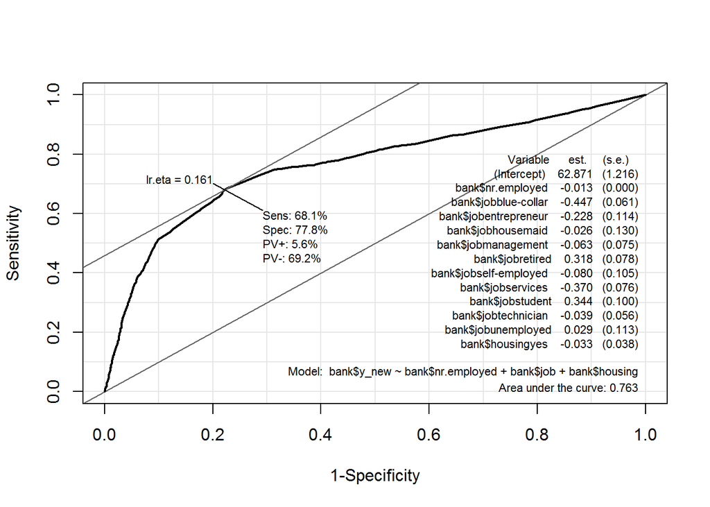

```r
#Output the sensitivity, specificity, and ROC plot
Epi::ROC(form=bank$y_new ~ bank$nr.employed+bank$job+bank$housing, plot="ROC")
p<-Epi::ROC(form=bank$y_new ~ bank$nr.employed+bank$job+bank$housing, plot="ROC")
```

```r
m7auc<-round(p$AUC,3)
#Pseudo Rsquared
m7csr2<-DescTools::PseudoR2(logmodel7, which="CoxSnell")
m7csr2
```

```
## CoxSnell
## 0.116146
```

```r
m7knr2<-DescTools::PseudoR2(logmodel7, which="Nagelkerke")
m7knr2
```

```
## Nagelkerke
##  0.2182509
```

The AUC of the model is: 0.763

The pseudo R square indicate that between 11.61% and 21.83% of the variability of responses to whether the customer opts for the term deposit or not.

```r
#Summary of the model with co-efficients
stargazer(logmodel7, type="text")
```

```
##
## =============================================
##                       Dependent variable:
##                   ---------------------------
##                              y_new
## ---------------------------------------------
## nr.employed                -0.013***
##                            (0.0002)
##
## jobblue-collar             -0.447***
##                             (0.061)
##
## jobentrepreneur            -0.228**
##                             (0.114)
##
## jobhousemaid                -0.026
##                             (0.130)
##
## jobmanagement               -0.063
##                             (0.075)
##
## jobretired                 0.318***
##                             (0.078)
##
## jobself-employed            -0.080
##                             (0.105)
##
## jobservices                -0.370***
##                             (0.076)
##
## jobstudent                 0.344***
##                             (0.100)
##
## jobtechnician               -0.039
##                             (0.056)
##
## jobunemployed                0.029
##                             (0.113)
##
## housingyes                  -0.033
##                             (0.038)
##
## Constant                   62.871***
##                             (1.216)
##
## ---------------------------------------------
## Observations                30,488
## Log Likelihood            -9,697.952
## Akaike Inf. Crit.         19,421.900
## =============================================
## Note:             *p<0.1; **p<0.05; ***p<0.01
```

Housing predictor rejected as Probability >0.05 and increase in AIC.

## Model-8 | nr.employed, job and loan as predictor

```r
logmodel8 <- glm(y_new ~ nr.employed+job+loan , data = bank, na.action = na.exclude, family = binomial(link=logit))

#Full summary of the model
summary(logmodel8)
```

```
##
## Call:
## glm(formula = y_new ~ nr.employed + job + loan, family = binomial(link = logit),
##     data = bank, na.action = na.exclude)
##
## Deviance Residuals:
##     Min       1Q   Median       3Q      Max
## -1.4610  -0.5399  -0.3103  -0.2964   2.6607
##
## Coefficients:
##                    Estimate Std. Error z value Pr(>|z|)
## (Intercept)      62.8100327  1.2142173  51.729  < 2e-16 ***
## nr.employed      -0.0125935  0.0002377 -52.983  < 2e-16 ***
## jobblue-collar   -0.4466366  0.0609321  -7.330 2.30e-13 ***
## jobentrepreneur  -0.2287957  0.1144904  -1.998 0.045675 *
## jobhousemaid     -0.0259604  0.1300826  -0.200 0.841818
## jobmanagement    -0.0633827  0.0754503  -0.840 0.400876
## jobretired        0.3185870  0.0781429   4.077 4.56e-05 ***
## jobself-employed -0.0801585  0.1045098  -0.767 0.443084
## jobservices      -0.3702712  0.0762032  -4.859 1.18e-06 ***
## jobstudent        0.3447269  0.0995386   3.463 0.000534 ***
## jobtechnician    -0.0399365  0.0563455  -0.709 0.478462
## jobunemployed     0.0285282  0.1126195   0.253 0.800025
## loanyes          -0.0337474  0.0519279  -0.650 0.515764
## ---
## Signif. codes:  0 '***' 0.001 '**' 0.01 '*' 0.05 '.' 0.1 ' ' 1
##
## (Dispersion parameter for binomial family taken to be 1)
##
##     Null deviance: 23160  on 30487  degrees of freedom
## Residual deviance: 19396  on 30475  degrees of freedom
## AIC: 19422
##
## Number of Fisher Scoring iterations: 5
```

```r
#Chi-square plus significance
lmtest::lrtest(logmodel4,logmodel8)
```

|  | #Df | LogLik | Df | Chisq | Pr(>Chisq) |
| --- | --- | --- | --- | --- | --- |
| 1 | 12 | -9698.336 | NA | NA | NA |
| 2 | 13 | -9698.124 | 1 | 0.4242494 | 0.5148242 |

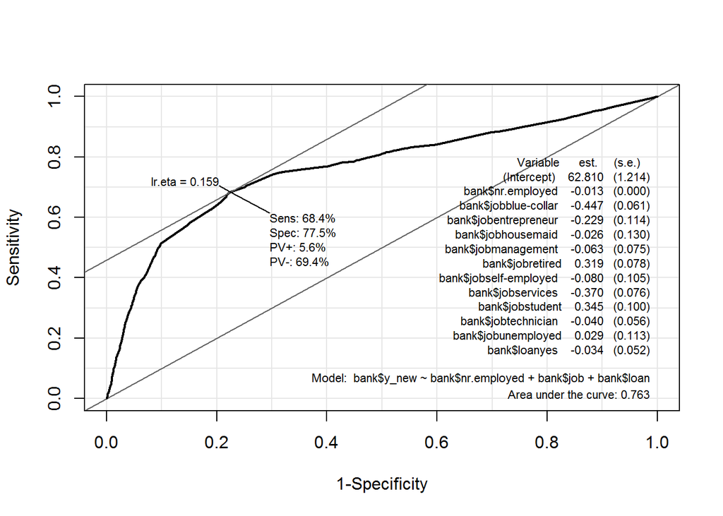

```r
#Output the sensitivity, specificity, and ROC plot
Epi::ROC(form=bank$y_new ~ bank$nr.employed+bank$job+bank$loan, plot="ROC")
p<-Epi::ROC(form=bank$y_new ~ bank$nr.employed+bank$job+bank$loan, plot="ROC")
```

```r
m8auc<-round(p$AUC,3)

#Pseudo Rsquared
m8csr2<-DescTools::PseudoR2(logmodel8, which="CoxSnell")
m8csr2
```

```
##  CoxSnell
## 0.1161361
```

```r
m8knr2<-DescTools::PseudoR2(logmodel8, which="Nagelkerke")
m8knr2
```

```
## Nagelkerke
##  0.2182321
```

The AUC of the model is: 0.763

The pseudo R square indicate that between 11.61% and 21.82% of the variability of responses to whether the customer opts for the term deposit or not.

```r
#Summary of the model with co-efficients
stargazer(logmodel8, type="text")
```

```
##
## =============================================
##                       Dependent variable:
##                   ---------------------------
##                              y_new
## ---------------------------------------------
## nr.employed                -0.013***
##                            (0.0002)
##
## jobblue-collar             -0.447***
##                             (0.061)
##
## jobentrepreneur            -0.229**
##                             (0.114)
##
## jobhousemaid                -0.026
##                             (0.130)
##
## jobmanagement               -0.063
##                             (0.075)
##
## jobretired                 0.319***
##                             (0.078)
##
## jobself-employed            -0.080
##                             (0.105)
##
## jobservices                -0.370***
##                             (0.076)
##
## jobstudent                 0.345***
##                             (0.100)
##
## jobtechnician               -0.040
##                             (0.056)
##
## jobunemployed                0.029
##                             (0.113)
##
## loanyes                     -0.034
##                             (0.052)
##
## Constant                   62.810***
##                             (1.214)
##
## ---------------------------------------------
## Observations                30,488
## Log Likelihood            -9,698.124
## Akaike Inf. Crit.         19,422.250
## =============================================
## Note:             *p<0.1; **p<0.05; ***p<0.01
```

Loan predictor rejected as Probability >0.05 and increase in AIC.

## Model-9 | nr.employed, job and contact as predictor

```r
logmodel9 <- glm(y_new ~ nr.employed+job+contact , data = bank, na.action = na.exclude, family = binomial(link=logit))

#Full summary of the model
summary(logmodel9)
```

```
##
## Call:
## glm(formula = y_new ~ nr.employed + job + contact, family = binomial(link = logit),
##     data = bank, na.action = na.exclude)
##
## Deviance Residuals:
##     Min       1Q   Median       3Q      Max
## -1.4697  -0.5675  -0.3284  -0.2567   2.7783
##
## Coefficients:
##                    Estimate Std. Error z value Pr(>|z|)
## (Intercept)      59.4738568  1.2439737  47.810  < 2e-16 ***
## nr.employed      -0.0119198  0.0002439 -48.879  < 2e-16 ***
## jobblue-collar   -0.4381031  0.0610441  -7.177 7.13e-13 ***
## jobentrepreneur  -0.2146976  0.1147274  -1.871  0.06129 .
## jobhousemaid      0.0105267  0.1302513   0.081  0.93559
## jobmanagement    -0.0672424  0.0755182  -0.890  0.37324
## jobretired        0.3278817  0.0782083   4.192 2.76e-05 ***
## jobself-employed -0.0777108  0.1046849  -0.742  0.45789
## jobservices      -0.3569569  0.0763127  -4.678 2.90e-06 ***
## jobstudent        0.3566703  0.0993465   3.590  0.00033 ***
## jobtechnician    -0.0488646  0.0563394  -0.867  0.38576
## jobunemployed     0.0584716  0.1126737   0.519  0.60380
## contacttelephone -0.5558782  0.0502959 -11.052  < 2e-16 ***
## ---
## Signif. codes:  0 '***' 0.001 '**' 0.01 '*' 0.05 '.' 0.1 ' ' 1
##
## (Dispersion parameter for binomial family taken to be 1)
##
##     Null deviance: 23160  on 30487  degrees of freedom
## Residual deviance: 19266  on 30475  degrees of freedom
## AIC: 19292
##
## Number of Fisher Scoring iterations: 5
```

```r
#Chi-square plus significance
lmtest::lrtest(logmodel4,logmodel9)
```

|  | #Df | LogLik | Df | Chisq | Pr(>Chisq) |
| --- | --- | --- | --- | --- | --- |
| 1 | 12 | -9698.336 | NA | NA | NA |
| 2 | 13 | -9633.076 | 1 | 130.5198 | 3.153692e-30 |

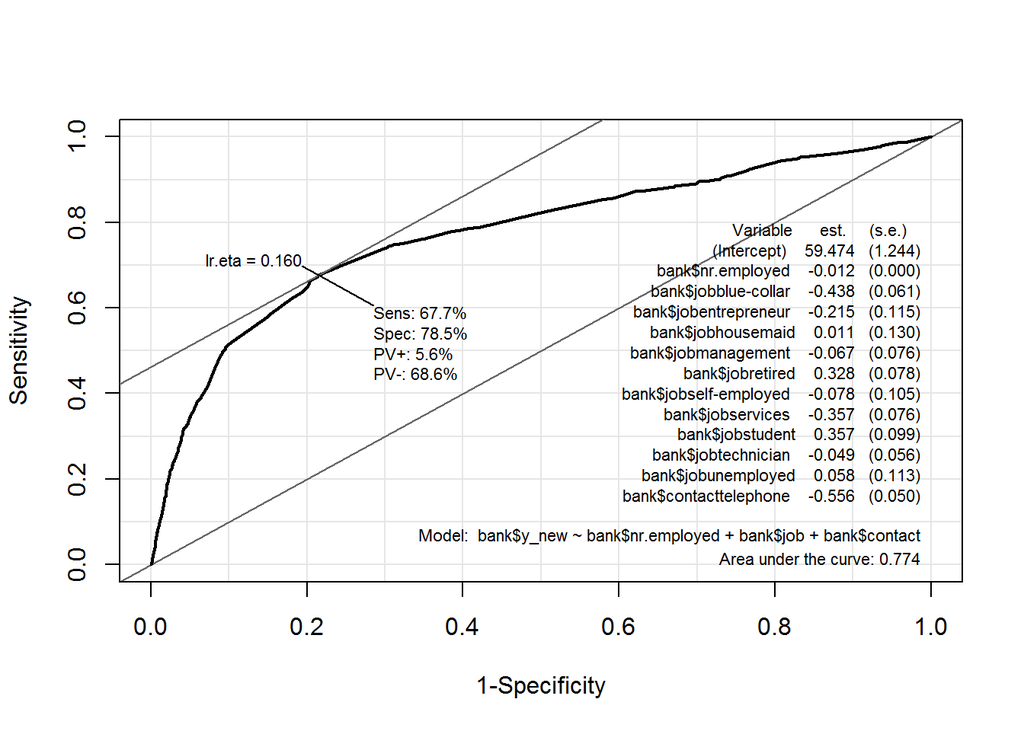

```r
#Output the sensitivity, specificity, and ROC plot
Epi::ROC(form=bank$y_new ~ bank$nr.employed+bank$job+bank$contact, plot="ROC")
p<-Epi::ROC(form=bank$y_new ~ bank$nr.employed+bank$job+bank$contact, plot="ROC")
```

```r
m9auc<-round(p$AUC,3)

#Pseudo Rsquared
m9csr2<-DescTools::PseudoR2(logmodel9, which="CoxSnell")
m9csr2
```

```
##  CoxSnell
## 0.1198996
```

```r
m9knr2<-DescTools::PseudoR2(logmodel9, which="Nagelkerke")
m9knr2
```

```
## Nagelkerke
##  0.2253042
```

The AUC of the model is: 0.774

The pseudo R square indicate that between 11.99% and 22.53% of the variability of responses to whether the customer opts for the term deposit or not.

```r
#Summary of the model with co-efficients
stargazer(logmodel9, type="text")
```

```
##
## =============================================
##                       Dependent variable:
##                   ---------------------------
##                              y_new
## ---------------------------------------------
## nr.employed                -0.012***
##                            (0.0002)
##
## jobblue-collar             -0.438***
##                             (0.061)
##
## jobentrepreneur             -0.215*
##                             (0.115)
##
## jobhousemaid                 0.011
##                             (0.130)
##
## jobmanagement               -0.067
##                             (0.076)
##
## jobretired                 0.328***
##                             (0.078)
##
## jobself-employed            -0.078
##                             (0.105)
##
## jobservices                -0.357***
##                             (0.076)
##
## jobstudent                 0.357***
##                             (0.099)
##
## jobtechnician               -0.049
##                             (0.056)
##
## jobunemployed                0.058
##                             (0.113)
##
## contacttelephone           -0.556***
##                             (0.050)
##
## Constant                   59.474***
##                             (1.244)
##
## ---------------------------------------------
## Observations                30,488
## Log Likelihood            -9,633.076
## Akaike Inf. Crit.         19,292.150
## =============================================
## Note:             *p<0.1; **p<0.05; ***p<0.01
```

Contact predictor selected. Rise in AUC and decrease in AIC.

## Model-10 | nr.employed, job, contact and month as predictor

```r
logmodel10 <- glm(y_new ~ nr.employed+job+contact+month , data = bank, na.action = na.exclude, family = binomial(link=logit))

#Full summary of the model
summary(logmodel10)
```

```
##
## Call:
## glm(formula = y_new ~ nr.employed + job + contact + month, family = binomial(link = logit),
##     data = bank, na.action = na.exclude)
##
## Deviance Residuals:
##     Min       1Q   Median       3Q      Max
## -1.6117  -0.4597  -0.3522  -0.2407   2.7628
##
## Coefficients:
##                    Estimate Std. Error z value Pr(>|z|)
## (Intercept)      61.0687469  1.4411886  42.374  < 2e-16 ***
## nr.employed      -0.0122238  0.0002832 -43.159  < 2e-16 ***
## jobblue-collar   -0.2672605  0.0629233  -4.247 2.16e-05 ***
## jobentrepreneur  -0.1209944  0.1162674  -1.041  0.29803
## jobhousemaid     -0.0378544  0.1326187  -0.285  0.77531
## jobmanagement    -0.0294713  0.0772108  -0.382  0.70268
## jobretired        0.2201851  0.0799203   2.755  0.00587 **
## jobself-employed -0.0821674  0.1072111  -0.766  0.44343
## jobservices      -0.2413195  0.0781761  -3.087  0.00202 **
## jobstudent        0.2738329  0.1018103   2.690  0.00715 **
## jobtechnician    -0.0492961  0.0574339  -0.858  0.39072
## jobunemployed     0.0036732  0.1155982   0.032  0.97465
## contacttelephone -0.4769793  0.0547740  -8.708  < 2e-16 ***
## monthaug          0.1385134  0.0753139   1.839  0.06589 .
## monthdec          0.3487249  0.1739553   2.005  0.04500 *
## monthjul          0.3242288  0.0772092   4.199 2.68e-05 ***
## monthjun          0.3567278  0.0811088   4.398 1.09e-05 ***
## monthmar          0.8629269  0.1091492   7.906 2.66e-15 ***
## monthmay         -0.6651671  0.0676910  -9.827  < 2e-16 ***
## monthnov         -0.2043643  0.0811463  -2.518  0.01179 *
## monthoct          0.0669309  0.1024772   0.653  0.51367
## monthsep         -0.2351255  0.1105306  -2.127  0.03340 *
## ---
## Signif. codes:  0 '***' 0.001 '**' 0.01 '*' 0.05 '.' 0.1 ' ' 1
##
## (Dispersion parameter for binomial family taken to be 1)
##
##     Null deviance: 23160  on 30487  degrees of freedom
## Residual deviance: 18791  on 30466  degrees of freedom
## AIC: 18835
##
## Number of Fisher Scoring iterations: 5
```

```r
#Chi-square plus significance
lmtest::lrtest(logmodel9,logmodel10)
```

|  | #Df | LogLik | Df | Chisq | Pr(>Chisq) |
| --- | --- | --- | --- | --- | --- |
| 1 | 13 | -9633.076 | NA | NA | NA |
| 2 | 22 | -9395.399 | 9 | 475.3547 | 1.083353e-96 |

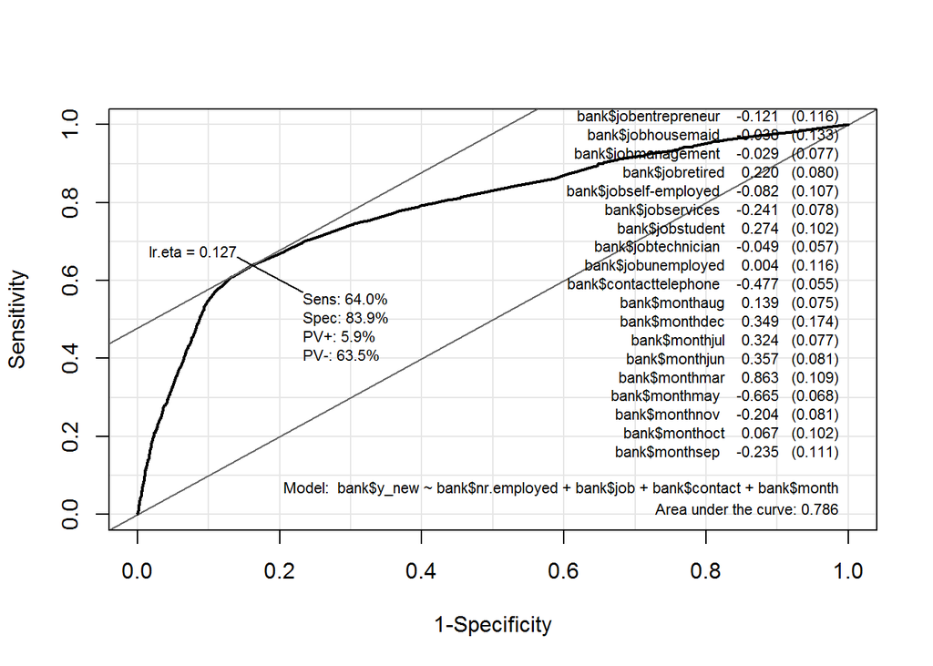

```r
#Output the sensitivity, specificity, and ROC plot
Epi::ROC(form=bank$y_new ~ bank$nr.employed+bank$job+bank$contact+bank$month, plot="ROC")
p<-Epi::ROC(form=bank$y_new ~ bank$nr.employed+bank$job+bank$contact+bank$month, plot="ROC")
```

```r
m10auc<-round(p$AUC,3)

#Pseudo Rsquared
m10csr2<-DescTools::PseudoR2(logmodel10, which="CoxSnell")
m10csr2
```

```
##  CoxSnell
## 0.1335153
```

```r
m10knr2<-DescTools::PseudoR2(logmodel10, which="Nagelkerke")
m10knr2
```

```
## Nagelkerke
##  0.2508895
```

The AUC of the model is: 0.786

The pseudo R square indicate that between 13.35% and 25.09% of the variability of responses to whether the customer opts for the term deposit or not.

```r
#Summary of the model with co-efficients
stargazer(logmodel10, type="text")
```

```
##
## =============================================
##                       Dependent variable:
##                   ---------------------------
##                              y_new
## ---------------------------------------------
## nr.employed                -0.012***
##                            (0.0003)
##
## jobblue-collar             -0.267***
##                             (0.063)
##
## jobentrepreneur             -0.121
##                             (0.116)
##
## jobhousemaid                -0.038
##                             (0.133)
##
## jobmanagement               -0.029
##                             (0.077)
##
## jobretired                 0.220***
##                             (0.080)
##
## jobself-employed            -0.082
##                             (0.107)
##
## jobservices                -0.241***
##                             (0.078)
##
## jobstudent                 0.274***
##                             (0.102)
##
## jobtechnician               -0.049
##                             (0.057)
##
## jobunemployed                0.004
##                             (0.116)
##
## contacttelephone           -0.477***
```

[output cut: 23 more lines]

```
## monthoct                     0.067
##                             (0.102)
##
## monthsep                   -0.235**
##                             (0.111)
##
## Constant                   61.069***
##                             (1.441)
##
## ---------------------------------------------
## Observations                30,488
## Log Likelihood            -9,395.399
## Akaike Inf. Crit.         18,834.800
## =============================================
## Note:             *p<0.1; **p<0.05; ***p<0.01
```

Month predictor selected. Rise in AUC and decrease in AIC.

## Model-11 | nr.employed, job, contact, month and day_of_week as predictor

```r
logmodel11 <- glm(y_new ~ nr.employed+job+contact+month+day_of_week, data = bank, na.action = na.exclude, family = binomial(link=logit))

#Full summary of the model
summary(logmodel11)
```

```
##
## Call:
## glm(formula = y_new ~ nr.employed + job + contact + month + day_of_week,
##     family = binomial(link = logit), data = bank, na.action = na.exclude)
##
## Deviance Residuals:
##     Min       1Q   Median       3Q      Max
## -1.6686  -0.4449  -0.3471  -0.2460   2.8515
##
## Coefficients:
##                    Estimate Std. Error z value Pr(>|z|)
## (Intercept)      61.4696630  1.4469249  42.483  < 2e-16 ***
## nr.employed      -0.0123114  0.0002843 -43.311  < 2e-16 ***
## jobblue-collar   -0.2687405  0.0630434  -4.263 2.02e-05 ***
## jobentrepreneur  -0.1220610  0.1164798  -1.048 0.294678
## jobhousemaid     -0.0361175  0.1331208  -0.271 0.786150
## jobmanagement    -0.0282589  0.0773678  -0.365 0.714922
## jobretired        0.2151844  0.0801094   2.686 0.007228 **
## jobself-employed -0.0768403  0.1073804  -0.716 0.474245
## jobservices      -0.2329000  0.0781504  -2.980 0.002881 **
## jobstudent        0.2658450  0.1019858   2.607 0.009142 **
## jobtechnician    -0.0466973  0.0575237  -0.812 0.416911
## jobunemployed     0.0011762  0.1158057   0.010 0.991897
## contacttelephone -0.4763271  0.0548500  -8.684  < 2e-16 ***
## monthaug          0.1162593  0.0757775   1.534 0.124976
## monthdec          0.3486430  0.1745642   1.997 0.045801 *
## monthjul          0.2967035  0.0776605   3.821 0.000133 ***
## monthjun          0.3498157  0.0818815   4.272 1.94e-05 ***
## monthmar          0.8593958  0.1098067   7.826 5.02e-15 ***
## monthmay         -0.6868104  0.0682489 -10.063  < 2e-16 ***
## monthnov         -0.2254301  0.0815738  -2.764 0.005718 **
## monthoct          0.0364632  0.1028206   0.355 0.722867
## monthsep         -0.2746436  0.1111251  -2.471 0.013455 *
## day_of_weekmon   -0.1773690  0.0630167  -2.815 0.004883 **
## day_of_weekthu    0.1469295  0.0605670   2.426 0.015271 *
## day_of_weektue    0.1197072  0.0623918   1.919 0.055030 .
## day_of_weekwed    0.2263349  0.0618037   3.662 0.000250 ***
## ---
## Signif. codes:  0 '***' 0.001 '**' 0.01 '*' 0.05 '.' 0.1 ' ' 1
##
## (Dispersion parameter for binomial family taken to be 1)
##
##     Null deviance: 23160  on 30487  degrees of freedom
## Residual deviance: 18737  on 30462  degrees of freedom
## AIC: 18789
##
## Number of Fisher Scoring iterations: 5
```

```r
#Chi-square plus significance
lmtest::lrtest(logmodel10,logmodel11)
```

|  | #Df | LogLik | Df | Chisq | Pr(>Chisq) |
| --- | --- | --- | --- | --- | --- |
| 1 | 22 | -9395.399 | NA | NA | NA |
| 2 | 26 | -9368.528 | 4 | 53.74185 | 5.960155e-11 |

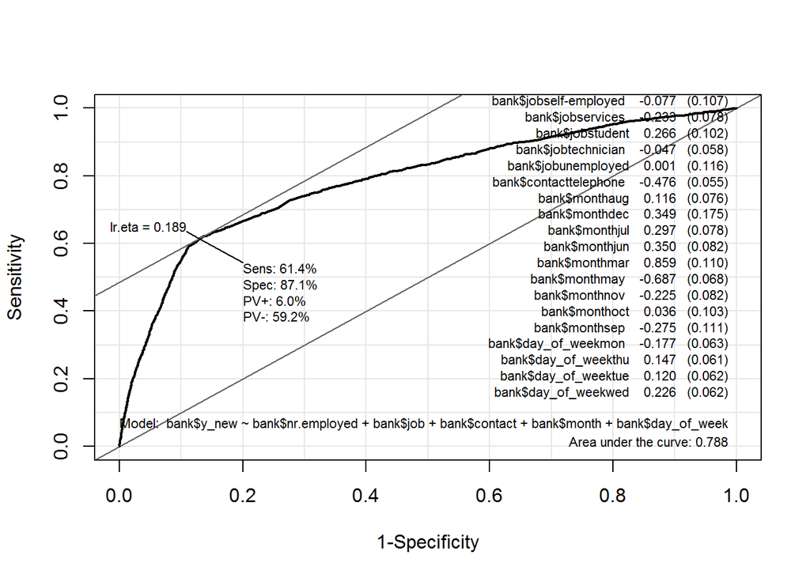

```r
#Output the sensitivity, specificity, and ROC plot
Epi::ROC(form=bank$y_new ~ bank$nr.employed+bank$job+bank$contact+bank$month+bank$day_of_week, plot="ROC")
p<-Epi::ROC(form=bank$y_new ~ bank$nr.employed+bank$job+bank$contact+bank$month+bank$day_of_week, plot="ROC")
```

```r
m11auc<-round(p$AUC,3)

#Pseudo Rsquared
m11csr2<-DescTools::PseudoR2(logmodel11, which="CoxSnell")
m11csr2
```

```
##  CoxSnell
## 0.1350413
```

```r
m11knr2<-DescTools::PseudoR2(logmodel11, which="Nagelkerke")
m11knr2
```

```
## Nagelkerke
##  0.2537571
```

The AUC of the model is: 0.788

The pseudo R square indicate that between 13.5% and 25.38% of the variability of responses to whether the customer opts for the term deposit or not.

```r
#Summary of the model with co-efficients
stargazer(logmodel11, type="text")
```

```
##
## =============================================
##                       Dependent variable:
##                   ---------------------------
##                              y_new
## ---------------------------------------------
## nr.employed                -0.012***
##                            (0.0003)
##
## jobblue-collar             -0.269***
##                             (0.063)
##
## jobentrepreneur             -0.122
##                             (0.116)
##
## jobhousemaid                -0.036
##                             (0.133)
##
## jobmanagement               -0.028
##                             (0.077)
##
## jobretired                 0.215***
##                             (0.080)
##
## jobself-employed            -0.077
##                             (0.107)
##
## jobservices                -0.233***
##                             (0.078)
##
## jobstudent                 0.266***
##                             (0.102)
##
## jobtechnician               -0.047
##                             (0.058)
##
## jobunemployed                0.001
##                             (0.116)
##
## contacttelephone           -0.476***
```

[output cut: 35 more lines]

```
## day_of_weektue              0.120*
##                             (0.062)
##
## day_of_weekwed             0.226***
##                             (0.062)
##
## Constant                   61.470***
##                             (1.447)
##
## ---------------------------------------------
## Observations                30,488
## Log Likelihood            -9,368.528
## Akaike Inf. Crit.         18,789.060
## =============================================
## Note:             *p<0.1; **p<0.05; ***p<0.01
```

day_of_week predictor selected. Rise in AUC and decrease in AIC.

## Model-12 | nr.employed, job, contact, month, day_of_week and campaign as predictor

```r
logmodel12 <- glm(y_new ~ nr.employed+job+contact+month+day_of_week+campaign , data = bank, na.action = na.exclude, family = binomial(link=logit))

#Full summary of the model
summary(logmodel12)
```

```
##
## Call:
## glm(formula = y_new ~ nr.employed + job + contact + month + day_of_week +
##     campaign, family = binomial(link = logit), data = bank, na.action = na.exclude)
##
## Deviance Residuals:
##     Min       1Q   Median       3Q      Max
## -1.6681  -0.4402  -0.3449  -0.2453   3.0668
##
## Coefficients:
##                    Estimate Std. Error z value Pr(>|z|)
## (Intercept)      60.7517376  1.4524503  41.827  < 2e-16 ***
## nr.employed      -0.0121512  0.0002857 -42.528  < 2e-16 ***
## jobblue-collar   -0.2755241  0.0630839  -4.368 1.26e-05 ***
## jobentrepreneur  -0.1273678  0.1164688  -1.094 0.274140
## jobhousemaid     -0.0391431  0.1330383  -0.294 0.768586
## jobmanagement    -0.0335685  0.0773714  -0.434 0.664388
## jobretired        0.2172520  0.0801654   2.710 0.006727 **
## jobself-employed -0.0775904  0.1074708  -0.722 0.470314
## jobservices      -0.2348646  0.0781547  -3.005 0.002655 **
## jobstudent        0.2602119  0.1019581   2.552 0.010706 *
## jobtechnician    -0.0492001  0.0575603  -0.855 0.392685
## jobunemployed    -0.0041887  0.1158556  -0.036 0.971159
## contacttelephone -0.4640285  0.0549431  -8.446  < 2e-16 ***
## monthaug          0.1265903  0.0758192   1.670 0.094992 .
## monthdec          0.3696602  0.1746179   2.117 0.034263 *
## monthjul          0.3243448  0.0778699   4.165 3.11e-05 ***
## monthjun          0.3566576  0.0819252   4.353 1.34e-05 ***
## monthmar          0.8793415  0.1100823   7.988 1.37e-15 ***
## monthmay         -0.6736656  0.0683376  -9.858  < 2e-16 ***
## monthnov         -0.2311826  0.0815134  -2.836 0.004566 **
## monthoct          0.0351453  0.1027454   0.342 0.732304
## monthsep         -0.2641791  0.1110986  -2.378 0.017412 *
## day_of_weekmon   -0.1770743  0.0630108  -2.810 0.004951 **
## day_of_weekthu    0.1397833  0.0606037   2.307 0.021082 *
## day_of_weektue    0.1054691  0.0624876   1.688 0.091442 .
## day_of_weekwed    0.2138336  0.0618716   3.456 0.000548 ***
## campaign         -0.0476053  0.0104105  -4.573 4.81e-06 ***
## ---
## Signif. codes:  0 '***' 0.001 '**' 0.01 '*' 0.05 '.' 0.1 ' ' 1
##
## (Dispersion parameter for binomial family taken to be 1)
##
##     Null deviance: 23160  on 30487  degrees of freedom
## Residual deviance: 18713  on 30461  degrees of freedom
## AIC: 18767
##
## Number of Fisher Scoring iterations: 5
```

```r
#Chi-square plus significance
lmtest::lrtest(logmodel11,logmodel12)
```

|  | #Df | LogLik | Df | Chisq | Pr(>Chisq) |
| --- | --- | --- | --- | --- | --- |
| 1 | 26 | -9368.528 | NA | NA | NA |
| 2 | 27 | -9356.734 | 1 | 23.58837 | 1.193062e-06 |

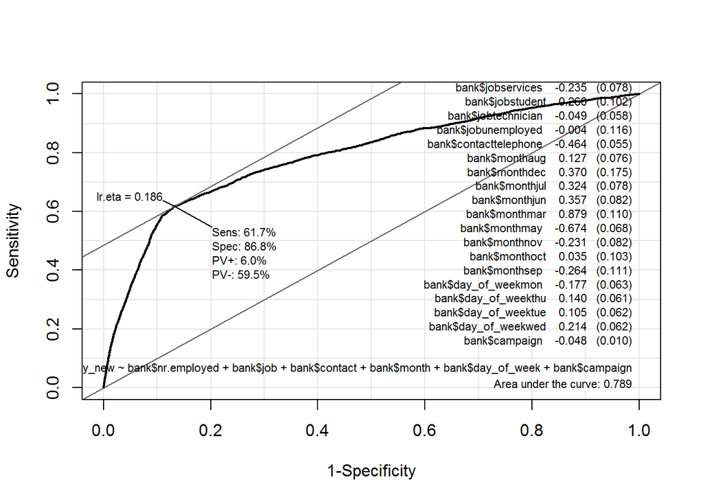

```r
#Output the sensitivity, specificity, and ROC plot
Epi::ROC(form=bank$y_new ~ bank$nr.employed+bank$job+bank$contact+bank$month+bank$day_of_week+bank$campaign, plot="ROC")
p<-Epi::ROC(form=bank$y_new ~ bank$nr.employed+bank$job+bank$contact+bank$month+bank$day_of_week+bank$campaign, plot="ROC")
```

```r
m12auc<-round(p$AUC,3)

#Pseudo Rsquared
m12csr2<-DescTools::PseudoR2(logmodel12, which="CoxSnell")
m12csr2
```

```
##  CoxSnell
## 0.1357102
```

```r
m12knr2<-DescTools::PseudoR2(logmodel12, which="Nagelkerke")
m12knr2
```

```
## Nagelkerke
##  0.2550141
```

The AUC of the model is: 0.789

The pseudo R square indicate that between 13.57% and 25.5% of the variability of responses to whether the customer opts for the term deposit or not.

```r
#Summary of the model with co-efficients
stargazer(logmodel12, type="text")
```

```
##
## =============================================
##                       Dependent variable:
##                   ---------------------------
##                              y_new
## ---------------------------------------------
## nr.employed                -0.012***
##                            (0.0003)
##
## jobblue-collar             -0.276***
##                             (0.063)
##
## jobentrepreneur             -0.127
##                             (0.116)
##
## jobhousemaid                -0.039
##                             (0.133)
##
## jobmanagement               -0.034
##                             (0.077)
##
## jobretired                 0.217***
##                             (0.080)
##
## jobself-employed            -0.078
##                             (0.107)
##
## jobservices                -0.235***
##                             (0.078)
##
## jobstudent                  0.260**
##                             (0.102)
##
## jobtechnician               -0.049
##                             (0.058)
##
## jobunemployed               -0.004
##                             (0.116)
##
## contacttelephone           -0.464***
```

[output cut: 38 more lines]

```
## day_of_weekwed             0.214***
##                             (0.062)
##
## campaign                   -0.048***
##                             (0.010)
##
## Constant                   60.752***
##                             (1.452)
##
## ---------------------------------------------
## Observations                30,488
## Log Likelihood            -9,356.734
## Akaike Inf. Crit.         18,767.470
## =============================================
## Note:             *p<0.1; **p<0.05; ***p<0.01
```

campaign Predictor selected. Rise in AUC and decrease in AIC.

## Model-13 | nr.employed, job, contact, month, day_of_week, campaign and pdays as predictor

```r
logmodel13 <- glm(y_new ~ nr.employed+job+contact+month+day_of_week+campaign+pdays , data = bank, na.action = na.exclude, family = binomial(link=logit))

#Full summary of the model
summary(logmodel13)
```

```
##
## Call:
## glm(formula = y_new ~ nr.employed + job + contact + month + day_of_week +
##     campaign + pdays, family = binomial(link = logit), data = bank,
##     na.action = na.exclude)
##
## Deviance Residuals:
##     Min       1Q   Median       3Q      Max
## -2.1675  -0.4315  -0.3459  -0.2532   3.0340
##
## Coefficients:
##                    Estimate Std. Error z value Pr(>|z|)
## (Intercept)       5.205e+01  1.548e+00  33.619  < 2e-16 ***
## nr.employed      -1.018e-02  3.081e-04 -33.056  < 2e-16 ***
## jobblue-collar   -2.594e-01  6.381e-02  -4.066 4.79e-05 ***
## jobentrepreneur  -1.096e-01  1.172e-01  -0.935 0.349939
## jobhousemaid     -7.480e-02  1.374e-01  -0.544 0.586242
## jobmanagement    -3.040e-02  7.874e-02  -0.386 0.699443
## jobretired        2.291e-01  8.225e-02   2.785 0.005348 **
## jobself-employed -3.233e-02  1.080e-01  -0.299 0.764674
## jobservices      -2.195e-01  7.927e-02  -2.769 0.005630 **
## jobstudent        2.316e-01  1.059e-01   2.186 0.028788 *
## jobtechnician    -5.450e-02  5.872e-02  -0.928 0.353360
## jobunemployed    -3.382e-02  1.193e-01  -0.284 0.776729
## contacttelephone -4.500e-01  5.576e-02  -8.070 7.04e-16 ***
## monthaug         -6.639e-02  7.815e-02  -0.849 0.395604
## monthdec          2.418e-01  1.816e-01   1.332 0.182996
## monthjul          1.610e-01  7.954e-02   2.024 0.042990 *
## monthjun          2.360e-01  8.365e-02   2.821 0.004788 **
## monthmar          8.731e-01  1.127e-01   7.748 9.35e-15 ***
## monthmay         -7.224e-01  6.956e-02 -10.385  < 2e-16 ***
## monthnov         -4.020e-01  8.378e-02  -4.798 1.60e-06 ***
## monthoct         -3.281e-04  1.061e-01  -0.003 0.997533
## monthsep         -3.542e-01  1.158e-01  -3.059 0.002224 **
## day_of_weekmon   -1.725e-01  6.418e-02  -2.688 0.007198 **
## day_of_weekthu    1.210e-01  6.185e-02   1.957 0.050396 .
## day_of_weektue    1.047e-01  6.368e-02   1.644 0.100235
## day_of_weekwed    2.079e-01  6.302e-02   3.298 0.000972 ***
## campaign         -4.627e-02  1.043e-02  -4.435 9.19e-06 ***
## pdays            -1.406e-03  6.981e-05 -20.146  < 2e-16 ***
## ---
## Signif. codes:  0 '***' 0.001 '**' 0.01 '*' 0.05 '.' 0.1 ' ' 1
##
## (Dispersion parameter for binomial family taken to be 1)
##
##     Null deviance: 23160  on 30487  degrees of freedom
## Residual deviance: 18295  on 30460  degrees of freedom
## AIC: 18351
##
## Number of Fisher Scoring iterations: 5
```

```r
#Chi-square plus significance
lmtest::lrtest(logmodel12,logmodel13)
```

|  | #Df | LogLik | Df | Chisq | Pr(>Chisq) |
| --- | --- | --- | --- | --- | --- |
| 1 | 27 | -9356.734 | NA | NA | NA |
| 2 | 28 | -9147.636 | 1 | 418.1949 | 6.030413e-93 |

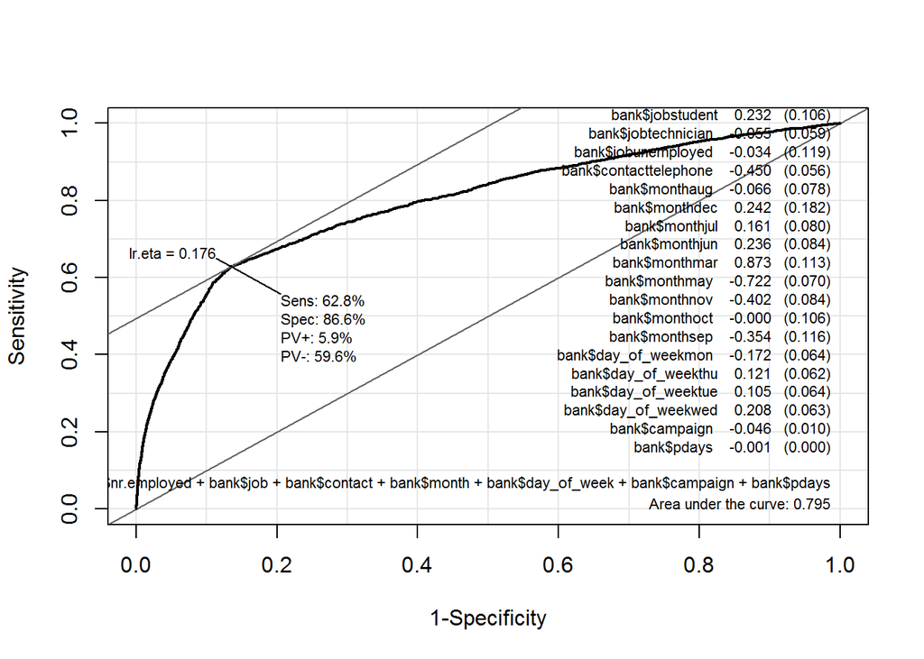

```r
#Output the sensitivity, specificity, and ROC plot
Epi::ROC(form=bank$y_new ~ bank$nr.employed+bank$job+bank$contact+bank$month+bank$day_of_week+bank$campaign+bank$pdays, plot="ROC")
p<-Epi::ROC(form=bank$y_new ~ bank$nr.employed+bank$job+bank$contact+bank$month+bank$day_of_week+bank$campaign+bank$pdays, plot="ROC")
```

```r
m13auc<-round(p$AUC,3)

#Pseudo Rsquared
m13csr2<-DescTools::PseudoR2(logmodel13, which="CoxSnell")
m13csr2
```

```
##  CoxSnell
## 0.1474845
```

```r
m13knr2<-DescTools::PseudoR2(logmodel13, which="Nagelkerke")
m13knr2
```

```
## Nagelkerke
##  0.2771392
```

The AUC of the model is: 0.795

The pseudo R square indicate that between 14.75% and 27.71% of the variability of responses to whether the customer opts for the term deposit or not.

```r
#Summary of the model with co-efficients
stargazer(logmodel13, type="text")
```

```
##
## =============================================
##                       Dependent variable:
##                   ---------------------------
##                              y_new
## ---------------------------------------------
## nr.employed                -0.010***
##                            (0.0003)
##
## jobblue-collar             -0.259***
##                             (0.064)
##
## jobentrepreneur             -0.110
##                             (0.117)
##
## jobhousemaid                -0.075
##                             (0.137)
##
## jobmanagement               -0.030
##                             (0.079)
##
## jobretired                 0.229***
##                             (0.082)
##
## jobself-employed            -0.032
##                             (0.108)
##
## jobservices                -0.219***
##                             (0.079)
##
## jobstudent                  0.232**
##                             (0.106)
##
## jobtechnician               -0.055
##                             (0.059)
##
## jobunemployed               -0.034
##                             (0.119)
##
## contacttelephone           -0.450***
```

[output cut: 41 more lines]

```
## campaign                   -0.046***
##                             (0.010)
##
## pdays                      -0.001***
##                            (0.0001)
##
## Constant                   52.055***
##                             (1.548)
##
## ---------------------------------------------
## Observations                30,488
## Log Likelihood            -9,147.636
## Akaike Inf. Crit.         18,351.270
## =============================================
## Note:             *p<0.1; **p<0.05; ***p<0.01
```

pdays predictor selected. Rise in AUC and decrease in AIC.

## Model-14 | nr.employed, job, contact, month, day_of_week, campaign, pdays and previous as predictor

```r
logmodel14 <- glm(y_new ~ nr.employed+job+contact+month+day_of_week+campaign+pdays+previous , data = bank, na.action = na.exclude, family = binomial(link=logit))

#Full summary of the model
summary(logmodel14)
```

```
##
## Call:
## glm(formula = y_new ~ nr.employed + job + contact + month + day_of_week +
##     campaign + pdays + previous, family = binomial(link = logit),
##     data = bank, na.action = na.exclude)
##
## Deviance Residuals:
##     Min       1Q   Median       3Q      Max
## -2.1560  -0.4240  -0.3427  -0.2525   3.0323
##
## Coefficients:
##                    Estimate Std. Error z value Pr(>|z|)
## (Intercept)       5.623e+01  1.630e+00  34.508  < 2e-16 ***
## nr.employed      -1.091e-02  3.206e-04 -34.044  < 2e-16 ***
## jobblue-collar   -2.588e-01  6.394e-02  -4.047 5.19e-05 ***
## jobentrepreneur  -1.110e-01  1.176e-01  -0.944  0.34541
## jobhousemaid     -7.614e-02  1.376e-01  -0.553  0.58012
## jobmanagement    -2.790e-02  7.888e-02  -0.354  0.72354
## jobretired        2.199e-01  8.247e-02   2.667  0.00765 **
## jobself-employed -3.775e-02  1.082e-01  -0.349  0.72706
## jobservices      -2.069e-01  7.939e-02  -2.606  0.00917 **
## jobstudent        2.424e-01  1.057e-01   2.292  0.02189 *
## jobtechnician    -5.406e-02  5.886e-02  -0.918  0.35838
## jobunemployed    -5.888e-02  1.196e-01  -0.492  0.62261
## contacttelephone -4.694e-01  5.577e-02  -8.416  < 2e-16 ***
## monthaug         -3.889e-02  7.837e-02  -0.496  0.61973
## monthdec          2.264e-01  1.824e-01   1.242  0.21440
## monthjul          1.831e-01  7.984e-02   2.294  0.02179 *
## monthjun          2.446e-01  8.388e-02   2.916  0.00354 **
## monthmar          8.599e-01  1.127e-01   7.631 2.32e-14 ***
## monthmay         -7.000e-01  6.980e-02 -10.029  < 2e-16 ***
## monthnov         -3.529e-01  8.419e-02  -4.192 2.77e-05 ***
## monthoct         -1.154e-02  1.066e-01  -0.108  0.91379
## monthsep         -3.601e-01  1.161e-01  -3.103  0.00192 **
## day_of_weekmon   -1.794e-01  6.433e-02  -2.789  0.00529 **
## day_of_weekthu    1.193e-01  6.198e-02   1.926  0.05415 .
## day_of_weektue    1.001e-01  6.385e-02   1.567  0.11708
## day_of_weekwed    2.069e-01  6.315e-02   3.276  0.00105 **
## campaign         -4.624e-02  1.045e-02  -4.425 9.63e-06 ***
## pdays            -1.794e-03  8.578e-05 -20.914  < 2e-16 ***
## previous         -3.087e-01  3.811e-02  -8.100 5.51e-16 ***
## ---
## Signif. codes:  0 '***' 0.001 '**' 0.01 '*' 0.05 '.' 0.1 ' ' 1
##
## (Dispersion parameter for binomial family taken to be 1)
##
##     Null deviance: 23160  on 30487  degrees of freedom
## Residual deviance: 18227  on 30459  degrees of freedom
## AIC: 18285
##
## Number of Fisher Scoring iterations: 5
```

```r
#Chi-square plus significance
lmtest::lrtest(logmodel13,logmodel14)
```

|  | #Df | LogLik | Df | Chisq | Pr(>Chisq) |
| --- | --- | --- | --- | --- | --- |
| 1 | 28 | -9147.636 | NA | NA | NA |
| 2 | 29 | -9113.698 | 1 | 67.8772 | 1.740013e-16 |

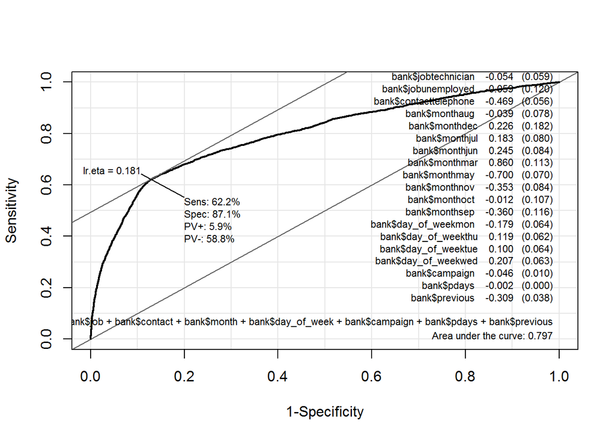

```r
#Output the sensitivity, specificity, and ROC plot
Epi::ROC(form=bank$y_new ~ bank$nr.employed+bank$job+bank$contact+bank$month+bank$day_of_week+bank$campaign+bank$pdays+bank$previous, plot="ROC")
p<-Epi::ROC(form=bank$y_new ~ bank$nr.employed+bank$job+bank$contact+bank$month+bank$day_of_week+bank$campaign+bank$pdays+bank$previous, plot="ROC")
```

```r
m14auc<-round(p$AUC,3)

#Pseudo Rsquared
m14csr2<-DescTools::PseudoR2(logmodel14, which="CoxSnell")
m14csr2
```

```
##  CoxSnell
## 0.1493804
```

```r
m14knr2<-DescTools::PseudoR2(logmodel14, which="Nagelkerke")
m14knr2
```

```
## Nagelkerke
##  0.2807018
```

The AUC of the model is: 0.797

The pseudo R square indicate that between 14.94% and 28.07% of the variability of responses to whether the customer opts for the term deposit or not.

```r
#Summary of the model with co-efficients
stargazer(logmodel14, type="text")
```

```
##
## =============================================
##                       Dependent variable:
##                   ---------------------------
##                              y_new
## ---------------------------------------------
## nr.employed                -0.011***
##                            (0.0003)
##
## jobblue-collar             -0.259***
##                             (0.064)
##
## jobentrepreneur             -0.111
##                             (0.118)
##
## jobhousemaid                -0.076
##                             (0.138)
##
## jobmanagement               -0.028
##                             (0.079)
##
## jobretired                 0.220***
##                             (0.082)
##
## jobself-employed            -0.038
##                             (0.108)
##
## jobservices                -0.207***
##                             (0.079)
##
## jobstudent                  0.242**
##                             (0.106)
##
## jobtechnician               -0.054
##                             (0.059)
##
## jobunemployed               -0.059
##                             (0.120)
##
## contacttelephone           -0.469***
```

[output cut: 44 more lines]

```
## pdays                      -0.002***
##                            (0.0001)
##
## previous                   -0.309***
##                             (0.038)
##
## Constant                   56.232***
##                             (1.630)
##
## ---------------------------------------------
## Observations                30,488
## Log Likelihood            -9,113.698
## Akaike Inf. Crit.         18,285.400
## =============================================
## Note:             *p<0.1; **p<0.05; ***p<0.01
```

Previous predictor selected. Rise in AUC and decrease in AIC.

## Model-15 | nr.employed, job, contact, month, day_of_week, campaign, pdays, previous and poutcome as predictor

```r
logmodel15 <- glm(y_new ~ nr.employed+job+contact+month+day_of_week+campaign+pdays+previous+poutcome , data = bank, na.action = na.exclude, family = binomial(link=logit))

#Full summary of the model
summary(logmodel15)
```

```
##
## Call:
## glm(formula = y_new ~ nr.employed + job + contact + month + day_of_week +
##     campaign + pdays + previous + poutcome, family = binomial(link = logit),
##     data = bank, na.action = na.exclude)
##
## Deviance Residuals:
##     Min       1Q   Median       3Q      Max
## -2.1235  -0.4202  -0.3432  -0.2547   3.0326
##
## Coefficients:
##                       Estimate Std. Error z value Pr(>|z|)
## (Intercept)         55.5679517  1.6488900  33.700  < 2e-16 ***
## nr.employed         -0.0109890  0.0003217 -34.155  < 2e-16 ***
## jobblue-collar      -0.2571657  0.0639895  -4.019 5.85e-05 ***
## jobentrepreneur     -0.1102895  0.1177125  -0.937 0.348790
## jobhousemaid        -0.0789177  0.1379009  -0.572 0.567134
## jobmanagement       -0.0283176  0.0790017  -0.358 0.720012
## jobretired           0.2214712  0.0826333   2.680 0.007358 **
## jobself-employed    -0.0358499  0.1082642  -0.331 0.740544
## jobservices         -0.2059404  0.0794612  -2.592 0.009550 **
## jobstudent           0.2355712  0.1060736   2.221 0.026363 *
## jobtechnician       -0.0515364  0.0588951  -0.875 0.381545
## jobunemployed       -0.0659039  0.1200934  -0.549 0.583162
## contacttelephone    -0.4911770  0.0560253  -8.767  < 2e-16 ***
## monthaug            -0.0606033  0.0786478  -0.771 0.440965
## monthdec             0.2189318  0.1831971   1.195 0.232063
## monthjul             0.1578421  0.0800879   1.971 0.048740 *
## monthjun             0.2325731  0.0840204   2.768 0.005639 **
## monthmar             0.8490070  0.1126725   7.535 4.88e-14 ***
## monthmay            -0.6992206  0.0699238 -10.000  < 2e-16 ***
## monthnov            -0.3585258  0.0844120  -4.247 2.16e-05 ***
## monthoct            -0.0152225  0.1067757  -0.143 0.886634
## monthsep            -0.3915726  0.1165897  -3.359 0.000784 ***
## day_of_weekmon      -0.1803789  0.0643872  -2.801 0.005087 **
## day_of_weekthu       0.1139649  0.0620769   1.836 0.066377 .
## day_of_weektue       0.1000671  0.0638889   1.566 0.117286
## day_of_weekwed       0.2021637  0.0632391   3.197 0.001390 **
## campaign            -0.0469326  0.0104660  -4.484 7.32e-06 ***
## pdays               -0.0011557  0.0002181  -5.300 1.16e-07 ***
## previous            -0.0743933  0.0587158  -1.267 0.205153
## poutcomenonexistent  0.4551394  0.0921911   4.937 7.94e-07 ***
## poutcomesuccess      0.7350619  0.2132774   3.447 0.000568 ***
## ---
## Signif. codes:  0 '***' 0.001 '**' 0.01 '*' 0.05 '.' 0.1 ' ' 1
##
## (Dispersion parameter for binomial family taken to be 1)
##
##     Null deviance: 23160  on 30487  degrees of freedom
## Residual deviance: 18196  on 30457  degrees of freedom
## AIC: 18258
##
## Number of Fisher Scoring iterations: 5
```

```r
#Chi-square plus significance
lmtest::lrtest(logmodel14,logmodel15)
```

|  | #Df | LogLik | Df | Chisq | Pr(>Chisq) |
| --- | --- | --- | --- | --- | --- |
| 1 | 29 | -9113.698 | NA | NA | NA |
| 2 | 31 | -9098.046 | 2 | 31.30236 | 1.59507e-07 |

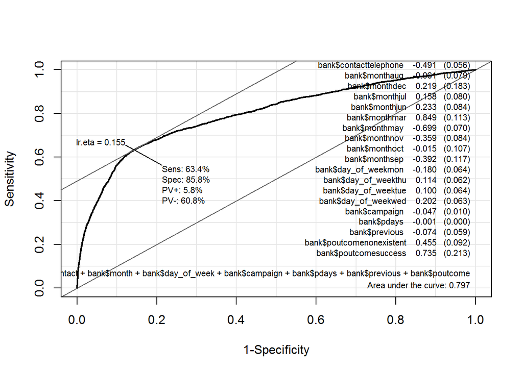

```r
#Output the sensitivity, specificity, and ROC plot
Epi::ROC(form=bank$y_new ~ bank$nr.employed+bank$job+bank$contact+bank$month+bank$day_of_week+bank$campaign+bank$pdays+bank$previous+bank$poutcome, plot="ROC")
p<-Epi::ROC(form=bank$y_new ~ bank$nr.employed+bank$job+bank$contact+bank$month+bank$day_of_week+bank$campaign+bank$pdays+bank$previous+bank$poutcome, plot="ROC")
```

```r
m15auc<-round(p$AUC,3)

#Pseudo Rsquared
m15csr2<-DescTools::PseudoR2(logmodel15, which="CoxSnell")
m15csr2
```

```
##  CoxSnell
## 0.1502533
```

```r
m15knr2<-DescTools::PseudoR2(logmodel15, which="Nagelkerke")
m15knr2
```

```
## Nagelkerke
##  0.2823421
```

The AUC of the model is: 0.797

The pseudo R square indicate that between 15.03% and 28.23% of the variability of responses to whether the customer opts for the term deposit or not.

```r
#Summary of the model with co-efficients
stargazer(logmodel15, type="text")
```

```
##
## ===============================================
##                         Dependent variable:
##                     ---------------------------
##                                y_new
## -----------------------------------------------
## nr.employed                  -0.011***
##                              (0.0003)
##
## jobblue-collar               -0.257***
##                               (0.064)
##
## jobentrepreneur               -0.110
##                               (0.118)
##
## jobhousemaid                  -0.079
##                               (0.138)
##
## jobmanagement                 -0.028
##                               (0.079)
##
## jobretired                   0.221***
##                               (0.083)
##
## jobself-employed              -0.036
##                               (0.108)
##
## jobservices                  -0.206***
##                               (0.079)
##
## jobstudent                    0.236**
##                               (0.106)
##
## jobtechnician                 -0.052
##                               (0.059)
##
## jobunemployed                 -0.066
##                               (0.120)
##
## contacttelephone             -0.491***
```

[output cut: 50 more lines]

```
## poutcomenonexistent          0.455***
##                               (0.092)
##
## poutcomesuccess              0.735***
##                               (0.213)
##
## Constant                     55.568***
##                               (1.649)
##
## -----------------------------------------------
## Observations                  30,488
## Log Likelihood              -9,098.046
## Akaike Inf. Crit.           18,258.090
## ===============================================
## Note:               *p<0.1; **p<0.05; ***p<0.01
```

poutcome predictor selected. Decrease in AIC. previous predictor rejected as Probability >0.05

## Model-16 | nr.employed, job, contact, month, day_of_week, campaign, pdays and poutcome as predictor

```r
logmodel16 <- glm(y_new ~ nr.employed+job+contact+month+day_of_week+campaign+pdays+poutcome , data = bank, na.action = na.exclude, family = binomial(link=logit))

#Full summary of the model
summary(logmodel16)
```

```
##
## Call:
## glm(formula = y_new ~ nr.employed + job + contact + month + day_of_week +
##     campaign + pdays + poutcome, family = binomial(link = logit),
##     data = bank, na.action = na.exclude)
##
## Deviance Residuals:
##     Min       1Q   Median       3Q      Max
## -2.1347  -0.4194  -0.3434  -0.2550   3.0328
##
## Coefficients:
##                       Estimate Std. Error z value Pr(>|z|)
## (Intercept)         55.1035049  1.6078344  34.272  < 2e-16 ***
## nr.employed         -0.0109335  0.0003188 -34.293  < 2e-16 ***
## jobblue-collar      -0.2568801  0.0639835  -4.015 5.95e-05 ***
## jobentrepreneur     -0.1098820  0.1176862  -0.934  0.35047
## jobhousemaid        -0.0792644  0.1379220  -0.575  0.56549
## jobmanagement       -0.0287250  0.0790066  -0.364  0.71617
## jobretired           0.2225122  0.0826342   2.693  0.00709 **
## jobself-employed    -0.0348523  0.1082586  -0.322  0.74750
## jobservices         -0.2067474  0.0794590  -2.602  0.00927 **
## jobstudent           0.2325334  0.1061380   2.191  0.02846 *
## jobtechnician       -0.0512521  0.0588902  -0.870  0.38414
## jobunemployed       -0.0643306  0.1201171  -0.536  0.59226
## contacttelephone    -0.4939262  0.0559951  -8.821  < 2e-16 ***
## monthaug            -0.0683185  0.0784106  -0.871  0.38359
## monthdec             0.2194785  0.1832288   1.198  0.23098
## monthjul             0.1501533  0.0798323   1.881  0.05999 .
## monthjun             0.2292541  0.0839643   2.730  0.00633 **
## monthmar             0.8472190  0.1126418   7.521 5.42e-14 ***
## monthmay            -0.7012599  0.0699062 -10.031  < 2e-16 ***
## monthnov            -0.3649648  0.0842755  -4.331 1.49e-05 ***
## monthoct            -0.0157077  0.1067327  -0.147  0.88300
## monthsep            -0.3964993  0.1165698  -3.401  0.00067 ***
## day_of_weekmon      -0.1801034  0.0643824  -2.797  0.00515 **
## day_of_weekthu       0.1132119  0.0620753   1.824  0.06818 .
## day_of_weektue       0.1004291  0.0638778   1.572  0.11590
## day_of_weekwed       0.2015361  0.0632391   3.187  0.00144 **
## campaign            -0.0471017  0.0104672  -4.500 6.80e-06 ***
## pdays               -0.0010581  0.0002041  -5.185 2.16e-07 ***
## poutcomenonexistent  0.5425343  0.0615247   8.818  < 2e-16 ***
## poutcomesuccess      0.8099590  0.2052836   3.946 7.96e-05 ***
## ---
## Signif. codes:  0 '***' 0.001 '**' 0.01 '*' 0.05 '.' 0.1 ' ' 1
##
## (Dispersion parameter for binomial family taken to be 1)
##
##     Null deviance: 23160  on 30487  degrees of freedom
## Residual deviance: 18198  on 30458  degrees of freedom
## AIC: 18258
##
## Number of Fisher Scoring iterations: 5
```

```r
#Chi-square plus significance
lmtest::lrtest(logmodel15,logmodel16)
```

|  | #Df | LogLik | Df | Chisq | Pr(>Chisq) |
| --- | --- | --- | --- | --- | --- |
| 1 | 31 | -9098.046 | NA | NA | NA |
| 2 | 30 | -9098.844 | -1 | 1.595138 | 0.2065936 |

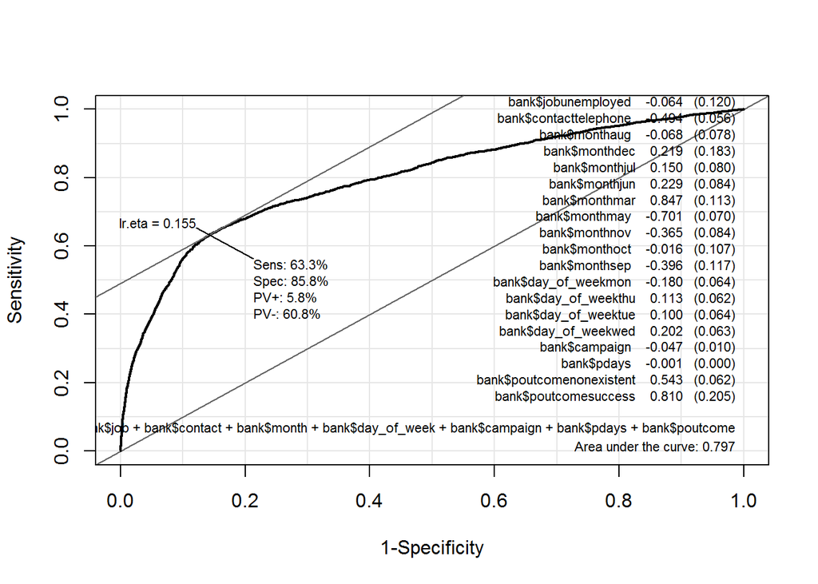

```r
#Output the sensitivity, specificity, and ROC plot
Epi::ROC(form=bank$y_new ~ bank$nr.employed+bank$job+bank$contact+bank$month+bank$day_of_week+bank$campaign+bank$pdays+bank$poutcome, plot="ROC")
p<-Epi::ROC(form=bank$y_new ~ bank$nr.employed+bank$job+bank$contact+bank$month+bank$day_of_week+bank$campaign+bank$pdays+bank$poutcome, plot="ROC")
```

```r
m16auc<-round(p$AUC,3)

#Pseudo Rsquared
m16csr2<-DescTools::PseudoR2(logmodel16, which="CoxSnell")
m16csr2
```

```
##  CoxSnell
## 0.1502088
```

```r
m16knr2<-DescTools::PseudoR2(logmodel16, which="Nagelkerke")
m16knr2
```

```
## Nagelkerke
##  0.2822586
```

The AUC of the model is: 0.797

The pseudo R square indicate that between 15.02% and 28.23% of the variability of responses to whether the customer opts for the term deposit or not.

```r
#Summary of the model with co-efficients
stargazer(logmodel16, type="text")
```

```
##
## ===============================================
##                         Dependent variable:
##                     ---------------------------
##                                y_new
## -----------------------------------------------
## nr.employed                  -0.011***
##                              (0.0003)
##
## jobblue-collar               -0.257***
##                               (0.064)
##
## jobentrepreneur               -0.110
##                               (0.118)
##
## jobhousemaid                  -0.079
##                               (0.138)
##
## jobmanagement                 -0.029
##                               (0.079)
##
## jobretired                   0.223***
##                               (0.083)
##
## jobself-employed              -0.035
##                               (0.108)
##
## jobservices                  -0.207***
##                               (0.079)
##
## jobstudent                    0.233**
##                               (0.106)
##
## jobtechnician                 -0.051
##                               (0.059)
##
## jobunemployed                 -0.064
##                               (0.120)
##
## contacttelephone             -0.494***
```

[output cut: 47 more lines]

```
## poutcomenonexistent          0.543***
##                               (0.062)
##
## poutcomesuccess              0.810***
##                               (0.205)
##
## Constant                     55.104***
##                               (1.608)
##
## -----------------------------------------------
## Observations                  30,488
## Log Likelihood              -9,098.844
## Akaike Inf. Crit.           18,257.690
## ===============================================
## Note:               *p<0.1; **p<0.05; ***p<0.01
```

# Confusion Matrix

```r
#Confusion matrix
regclass::confusion_matrix(logmodel16)
```

```
##          Predicted 0 Predicted 1 Total
## Actual 0       26144         485 26629
## Actual 1        2898         961  3859
## Total          29042        1446 30488
```

# Check the assumption of linearity of independent variables and log odds using a Hosmer-Lemeshow test

```r
generalhoslem::logitgof(bank$y_new, fitted(logmodel16))
```

```
##
##  Hosmer and Lemeshow test (binary model)
##
## data:  bank$y_new, fitted(logmodel16)
## X-squared = 46.525, df = 8, p-value = 1.888e-07
```

# Check the assumption of Collinearity

```r
vifmodel<-car::vif(logmodel16)
vifmodel
```

```
##                  GVIF Df GVIF^(1/(2*Df))
## nr.employed  1.924930  1        1.387418
## job          1.168470 10        1.007815
## contact      1.224666  1        1.106646
## month        2.013692  9        1.039653
## day_of_week  1.040825  4        1.005014
## campaign     1.038211  1        1.018926
## pdays        9.657861  1        3.107710
## poutcome    10.685568  2        1.808004
```

```r
#Tolerance
1/vifmodel
```

```
##                   GVIF        Df GVIF^(1/(2*Df))
## nr.employed 0.51949947 1.0000000       0.7207631
## job         0.85582029 0.1000000       0.9922455
## contact     0.81654915 1.0000000       0.9036311
## month       0.49660020 0.1111111       0.9618592
## day_of_week 0.96077653 0.2500000       0.9950108
## campaign    0.96319515 1.0000000       0.9814251
## pdays       0.10354260 1.0000000       0.3217804
## poutcome    0.09358417 0.5000000       0.5530961
```

## Finding

We created a model with above attributes. Examination for multicollinearity showed that the tolerance and variance influence factor measures for ‘Number of days that passed by after the client was last contacted from a previous campaign’ (pdays) predictor were not within acceptable levels (tolerance >0.4, VIF <2.5 ) as outlined in Tarling (2008). So, ‘Number of days that passed by after the client was last contacted from a previous campaign’ (pdays) is removed from the final model.

## Model-16 | nr.employed, job, contact, month, day_of_week, campaign and poutcome as predictor

```r
logmodel16 <- glm(y_new ~ nr.employed+job+contact+month+day_of_week+campaign+poutcome , data = bank, na.action = na.exclude, family = binomial(link=logit))

#Full summary of the model
summary(logmodel16)
```

```
##
## Call:
## glm(formula = y_new ~ nr.employed + job + contact + month + day_of_week +
##     campaign + poutcome, family = binomial(link = logit), data = bank,
##     na.action = na.exclude)
##
## Deviance Residuals:
##     Min       1Q   Median       3Q      Max
## -2.1327  -0.4219  -0.3436  -0.2535   3.0342
##
## Coefficients:
##                       Estimate Std. Error z value Pr(>|z|)
## (Intercept)         54.7185427  1.6032781  34.129  < 2e-16 ***
## nr.employed         -0.0110550  0.0003173 -34.837  < 2e-16 ***
## jobblue-collar      -0.2573897  0.0639304  -4.026 5.67e-05 ***
## jobentrepreneur     -0.1133326  0.1176635  -0.963 0.335451
## jobhousemaid        -0.0782359  0.1378843  -0.567 0.570441
## jobmanagement       -0.0308479  0.0789906  -0.391 0.696148
## jobretired           0.2223942  0.0825339   2.695 0.007048 **
## jobself-employed    -0.0390383  0.1082181  -0.361 0.718296
## jobservices         -0.2098287  0.0793838  -2.643 0.008212 **
## jobstudent           0.2492782  0.1058389   2.355 0.018510 *
## jobtechnician       -0.0491686  0.0588024  -0.836 0.403061
## jobunemployed       -0.0686524  0.1201111  -0.572 0.567611
## contacttelephone    -0.4885795  0.0559565  -8.731  < 2e-16 ***
## monthaug            -0.0420663  0.0781115  -0.539 0.590203
## monthdec             0.2148782  0.1828792   1.175 0.240005
## monthjul             0.1711817  0.0796709   2.149 0.031665 *
## monthjun             0.2422754  0.0838293   2.890 0.003851 **
## monthmar             0.8572453  0.1124199   7.625 2.43e-14 ***
## monthmay            -0.6960447  0.0698094  -9.971  < 2e-16 ***
## monthnov            -0.3390450  0.0839532  -4.039 5.38e-05 ***
## monthoct            -0.0041574  0.1065160  -0.039 0.968866
## monthsep            -0.3954920  0.1163479  -3.399 0.000676 ***
## day_of_weekmon      -0.1773070  0.0643158  -2.757 0.005837 **
## day_of_weekthu       0.1137130  0.0620198   1.833 0.066729 .
## day_of_weektue       0.1017358  0.0638106   1.594 0.110860
## day_of_weekwed       0.2021254  0.0631635   3.200 0.001374 **
## campaign            -0.0467287  0.0104572  -4.469 7.87e-06 ***
## poutcomenonexistent  0.4776465  0.0594103   8.040 9.00e-16 ***
## poutcomesuccess      1.7851274  0.0839816  21.256  < 2e-16 ***
## ---
## Signif. codes:  0 '***' 0.001 '**' 0.01 '*' 0.05 '.' 0.1 ' ' 1
##
## (Dispersion parameter for binomial family taken to be 1)
##
##     Null deviance: 23160  on 30487  degrees of freedom
## Residual deviance: 18224  on 30459  degrees of freedom
## AIC: 18282
##
## Number of Fisher Scoring iterations: 5
```

```r
#Chi-square plus significance
lmtest::lrtest(logmodel16)
```

|  | #Df | LogLik | Df | Chisq | Pr(>Chisq) |
| --- | --- | --- | --- | --- | --- |
| 1 | 29 | -9112.011 | NA | NA | NA |
| 2 | 1 | -11580.028 | -28 | 4936.034 | 0 |

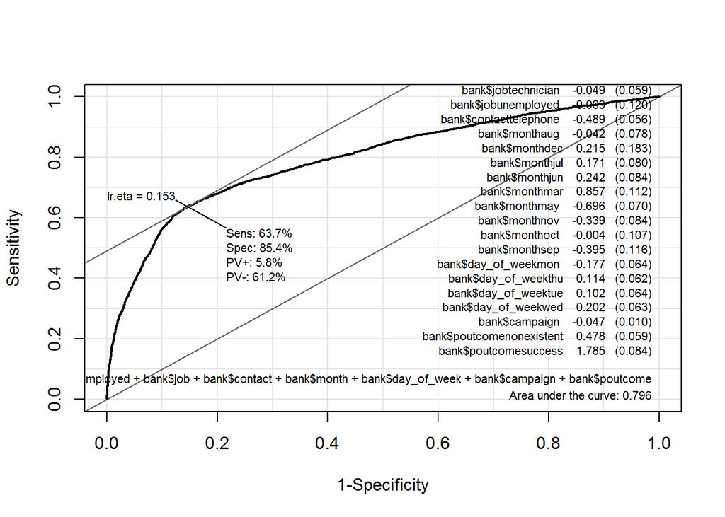

```r
#Output the sensitivity, specificity, and ROC plot
Epi::ROC(form=bank$y_new ~ bank$nr.employed+bank$job+bank$contact+bank$month+bank$day_of_week+bank$campaign+bank$poutcome, plot="ROC")
p<-Epi::ROC(form=bank$y_new ~ bank$nr.employed+bank$job+bank$contact+bank$month+bank$day_of_week+bank$campaign+bank$poutcome, plot="ROC")
```

```r
m16auc<-round(p$AUC,3)

#Pseudo Rsquared
m16csr2<-DescTools::PseudoR2(logmodel16, which="CoxSnell")
m16csr2
```

```
##  CoxSnell
## 0.1494745
```

```r
m16knr2<-DescTools::PseudoR2(logmodel16, which="Nagelkerke")
m16knr2
```

```
## Nagelkerke
##  0.2808787
```

The AUC of the model is: 0.796

The pseudo R square indicate that between 14.95% and 28.09% of the variability of responses to whether the customer opts for the term deposit or not.

```r
#Summary of the model with co-efficients
stargazer(logmodel16, type="text")
```

```
##
## ===============================================
##                         Dependent variable:
##                     ---------------------------
##                                y_new
## -----------------------------------------------
## nr.employed                  -0.011***
##                              (0.0003)
##
## jobblue-collar               -0.257***
##                               (0.064)
##
## jobentrepreneur               -0.113
##                               (0.118)
##
## jobhousemaid                  -0.078
##                               (0.138)
##
## jobmanagement                 -0.031
##                               (0.079)
##
## jobretired                   0.222***
##                               (0.083)
##
## jobself-employed              -0.039
##                               (0.108)
##
## jobservices                  -0.210***
##                               (0.079)
##
## jobstudent                    0.249**
##                               (0.106)
##
## jobtechnician                 -0.049
##                               (0.059)
##
## jobunemployed                 -0.069
##                               (0.120)
##
## contacttelephone             -0.489***
```

[output cut: 44 more lines]

```
## poutcomenonexistent          0.478***
##                               (0.059)
##
## poutcomesuccess              1.785***
##                               (0.084)
##
## Constant                     54.719***
##                               (1.603)
##
## -----------------------------------------------
## Observations                  30,488
## Log Likelihood              -9,112.011
## Akaike Inf. Crit.           18,282.020
## ===============================================
## Note:               *p<0.1; **p<0.05; ***p<0.01
```